# IE 360- Project

## 3.2 Exploratory Data Analysis

Total sum of production of the each day is plotted to understand data better. It can be observed that there is increasing trend towards the summer months.

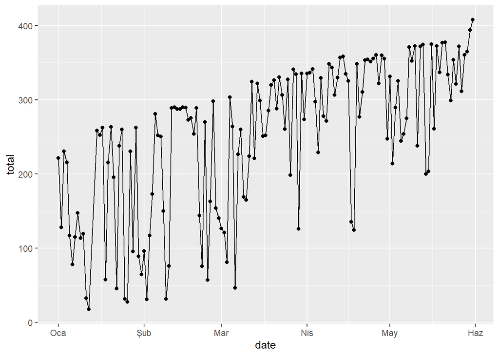

```r
daily_series=newdata[,list(total=sum(production)),by=list(date)]
ggplot(daily_series, aes(date,total, group=1)) + geom_line() +geom_point()
```

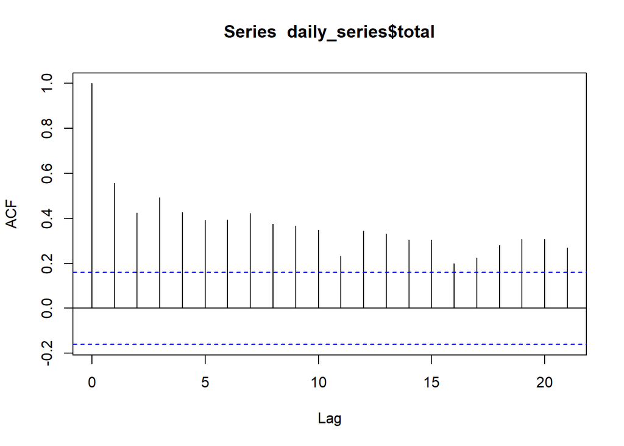

```r
acf(daily_series$total)
```

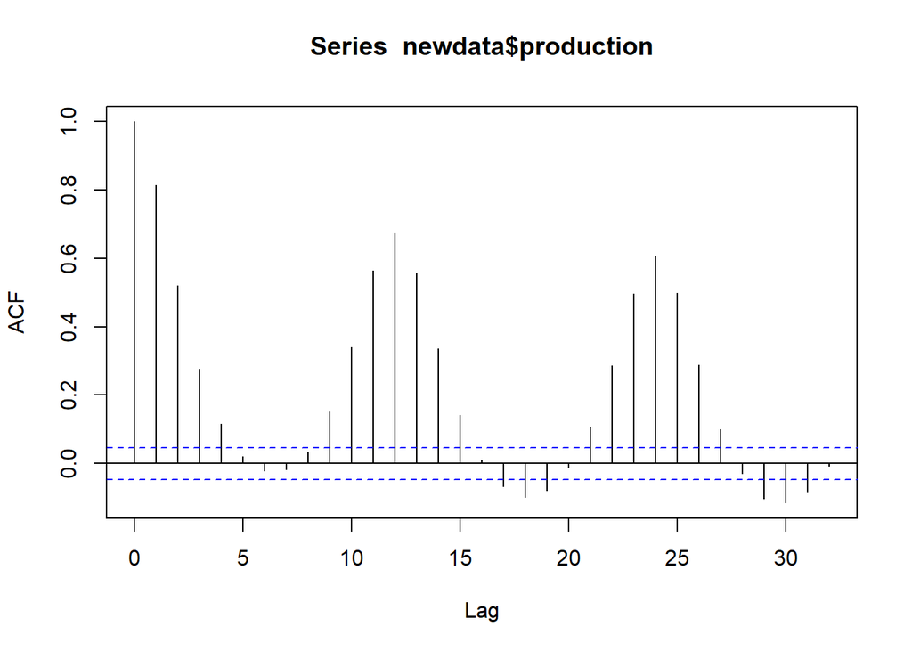

```r
acf(newdata$production)
```

From the ggpairs and correlation plot, we can see that temperature, cloud low layer, rel humidty and dswrf have significant but almost equally weighted effect on production amount. However, there are also significant correlations between these variables so some of these variables’ effect might be explained by using the others’ effect.Thus, in our regression models we tried to use combination of different parameters at each iteration to obtain better model.

Also the reason behind observing high autocorrelation values at lag 12 and 24 is because we only use 12 hours of the day since we removed the hours that sun doesn’t appear.

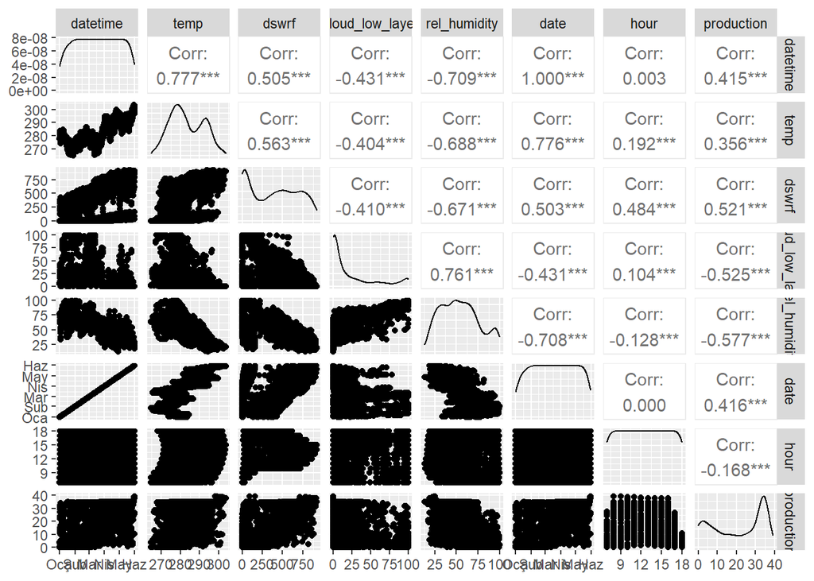

```r
ggpairs(newdata)
```

```r
basedata=newdata[,-c("date")]
basedata=basedata[,-c("hour")]
basedata=basedata[,-c("datetime")]
head(basedata,25)
```

```
##         temp      dswrf cloud_low_layer rel_humidity production
##  1: 277.8907   0.000000        5.400000     76.45556      0.000
##  2: 277.7452   0.000000        5.322222     76.35556      3.937
##  3: 279.0398   7.011111        5.544444     73.51111     22.082
##  4: 281.0552 192.448889        6.933333     66.41111     29.388
##  5: 282.0202 265.744444        5.988889     63.35556     32.253
##  6: 282.7694 322.657778        6.144444     61.52222     30.557
##  7: 283.2710 361.995556        7.744444     60.75556     30.553
##  8: 283.5339 383.277778        8.844444     60.86667     31.245
##  9: 283.5264 384.095556        9.966667     61.84444     27.089
## 10: 283.3286 264.642222       22.166667     64.43333     12.915
## 11: 282.2923 196.288889       22.655556     71.82222      1.388
## 12: 280.4584 136.191111       22.133333     77.63333      0.000
## 13: 278.3409   0.000000       16.644444     77.95556      0.000
## 14: 278.2839   0.000000       21.633333     77.90000      2.487
## 15: 279.1958   5.028889       25.911111     76.45556     10.804
## 16: 280.1223 125.148889       26.844444     73.95556     23.685
## 17: 280.8929 189.297778       32.311111     71.33333     13.450
## 18: 281.1116 230.284444       37.411111     71.56667     14.834
## 19: 281.1640 256.520000       42.233333     72.27778     23.813
## 20: 281.0467 265.962222       44.533333     72.90000     16.729
## 21: 280.8843 266.622222       45.355556     70.77778     11.023
## 22: 280.9829 247.566667       33.677778     66.73333      9.920
## 23: 280.6103 192.028889       26.911111     65.50000      1.326
## 24: 279.4642 133.917778       25.100000     65.36667      0.000
## 25: 274.0442   0.000000        6.388889     71.40000      0.030
##         temp      dswrf cloud_low_layer rel_humidity production
```

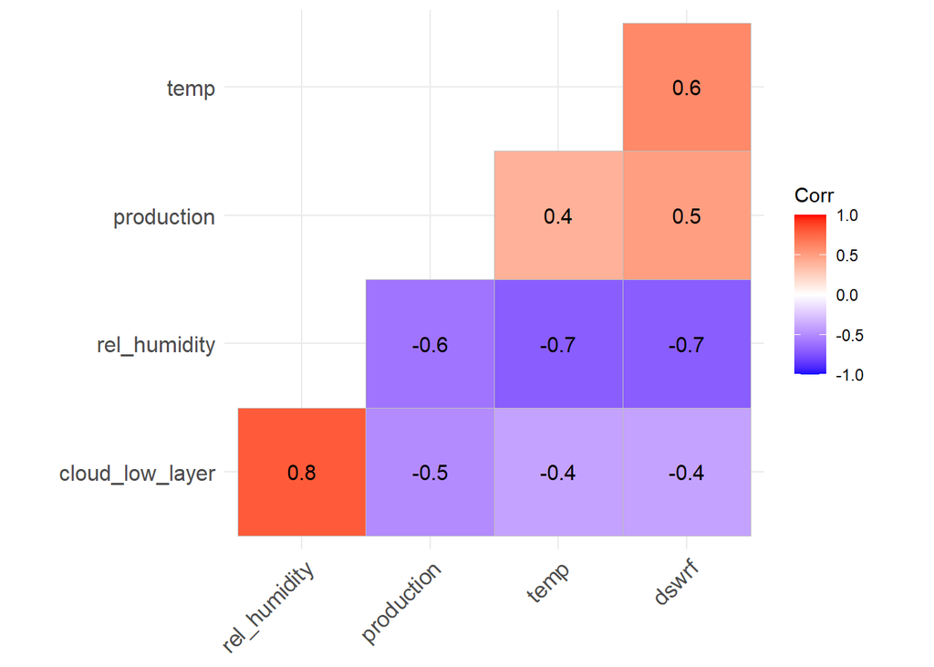

```r
corr<-round(cor(basedata),1)
ggcorrplot(corr,hc.order=TRUE,type="lower",lab=TRUE)
```

## 3.3 Regression Approach

We applied two different approaches to the regression method. First of all, we tried to create a base model over the production rate and improve it using different regressors. Since the predictions we applied on the test data and the production rate rates in the data were not as close as we desired, we tried to create the model in a different way. For this, we tried to approach the real data with our predictions by building a different model for each hour. By examining the given data hour by hour, we developed our models and made predictions and obtained closer results.

# 3.3.1 Regression Approach based on Production Amount

```r
newdata2=mergeddata[mergeddata$date >="2022-01-01",]
datapn<-data.table(newdata)
datapn2<-newdata2
dataph5<-datapn2[hour==5]
dataph6<-datapn2[ hour==6]
dataph7<-datapn2[hour==7]
dataph8<-datapn2[ hour==8]
dataph9<-datapn2[hour==9]
dataph10<-datapn2[ hour==10]
dataph11<-datapn2[ hour==11]
dataph12<-datapn2[hour==12]
dataph13<-datapn2[ hour==13]
dataph14<-datapn2[hour==14]
dataph15<-datapn2[ hour==15]
dataph16<-datapn2[ hour==16]
dataph17<-datapn2[hour==17]
dataph18<-datapn2[ hour==18]
dataph19<-datapn2[ hour==19]
dataph20<-datapn2[hour==20]
```

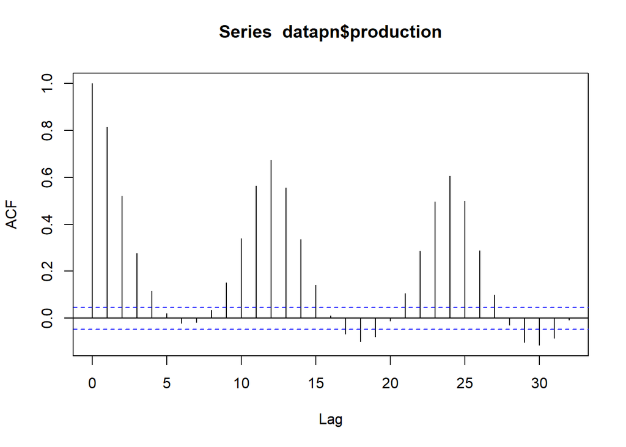

```r
datapn<-data.table(newdata)
#head(datapn,15)
acf(datapn$production)
lag15<-shift(datapn$production, n=15L, fill=NA)
datapn$lag15<-lag15
acf(datapn$production)
```

```r
lag14<-shift(datapn$production, n=14L, fill=NA)
datapn$lag14<-lag14
lag13<-shift(datapn$production, n=13L, fill=NA)
datapn$lag13<-lag13
lag12<-shift(datapn$production, n=12L, fill=NA)
datapn$lag12<-lag12
lag11<-shift(datapn$production, n=11L, fill=NA)
datapn$lag11<-lag11
lag16<-shift(datapn$production, n=16L, fill=NA)
datapn$lag6<-lag16
#lag8<-shift(datapn$production, n=8L, fill=NA)
#datapn$lag8<-lag8
lag1<-shift(datapn$production, n=1L, fill=NA)
datapn$lag1<-lag1
lag2<-shift(datapn$production, n=2L, fill=NA)
datapn$lag2<-lag2
datapn$hoursoftheday<-as.factor(datapn$hour)
datapn$season<-as.factor(quarter(datapn$date))
datapn[,tmax:=max(temp),by=date]
datapn[,tmin:=min(temp),by=date]
trend<-c(1:nrow((datapn)))
datapn$trend<-trend
lag1dswrf<-shift(datapn$dswrf, n=1L, fill=NA)
datapn$lag1dswrf<-lag1dswrf
lag12dswrf<-shift(datapn$dswrf, n=12L, fill=NA)
datapn$lag12dswrf<-lag12dswrf

#datapn[,trend:=c(1:140),by=date]
#datapn$sun[datapn$hour>7 & datapn$hour<19]<-1
#datapn[is.na(sun),sun:=0]
#datapn$sun<-as.factor(datapn$sun)
#datapn$month<-as.facto?(month(datapn$date))
```

```r
lm0<-lm(production~dswrf,data = datapn)
summary(lm0)
```

```
##
## Call:
## lm(formula = production ~ dswrf, data = datapn)
##
## Residuals:
##     Min      1Q  Median      3Q     Max
## -28.070 -10.411   1.720   8.126  25.370
##
## Coefficients:
##              Estimate Std. Error t value Pr(>|t|)
## (Intercept) 1.151e+01  4.483e-01   25.67   <2e-16 ***
## dswrf       2.367e-02  9.175e-04   25.80   <2e-16 ***
## ---
## Signif. codes:  0 '***' 0.001 '**' 0.01 '*' 0.05 '.' 0.1 ' ' 1
##
## Residual standard error: 11.42 on 1786 degrees of freedom
## Multiple R-squared:  0.2715, Adjusted R-squared:  0.2711
## F-statistic: 665.5 on 1 and 1786 DF,  p-value: < 2.2e-16
```

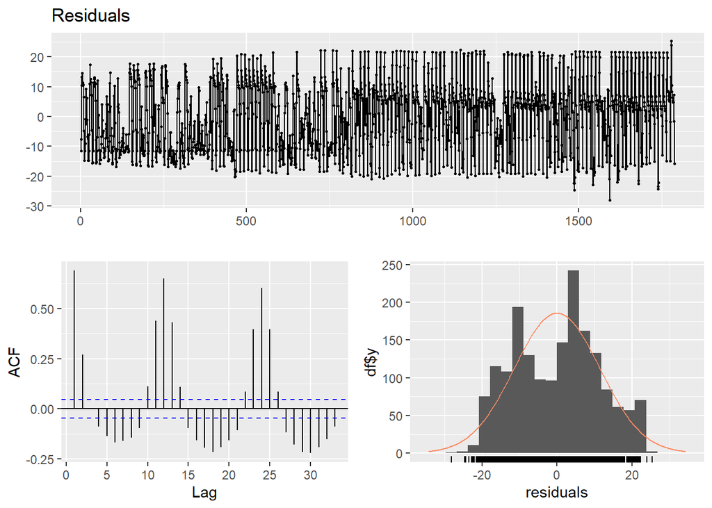

```
##
##  Breusch-Godfrey test for serial correlation of order up to 10
##
## data:  Residuals
## LM test = 1129, df = 10, p-value < 2.2e-16
```

```r
checkresiduals(lm0)
```

```r
#################################################


lm2<-lm(production~dswrf+lag12,data = datapn)
summary(lm2)
```

```
##
## Call:
## lm(formula = production ~ dswrf + lag12, data = datapn)
##
## Residuals:
##      Min       1Q   Median       3Q      Max
## -25.9505  -6.0113   0.2098   5.9275  29.4212
##
## Coefficients:
##              Estimate Std. Error t value Pr(>|t|)
## (Intercept) 4.1405056  0.4332831   9.556   <2e-16 ***
## dswrf       0.0129309  0.0008166  15.835   <2e-16 ***
## lag12       0.5595564  0.0180233  31.046   <2e-16 ***
## ---
## Signif. codes:  0 '***' 0.001 '**' 0.01 '*' 0.05 '.' 0.1 ' ' 1
##
## Residual standard error: 9.192 on 1773 degrees of freedom
##   (12 observations deleted due to missingness)
## Multiple R-squared:  0.528,  Adjusted R-squared:  0.5275
## F-statistic: 991.8 on 2 and 1773 DF,  p-value: < 2.2e-16
```

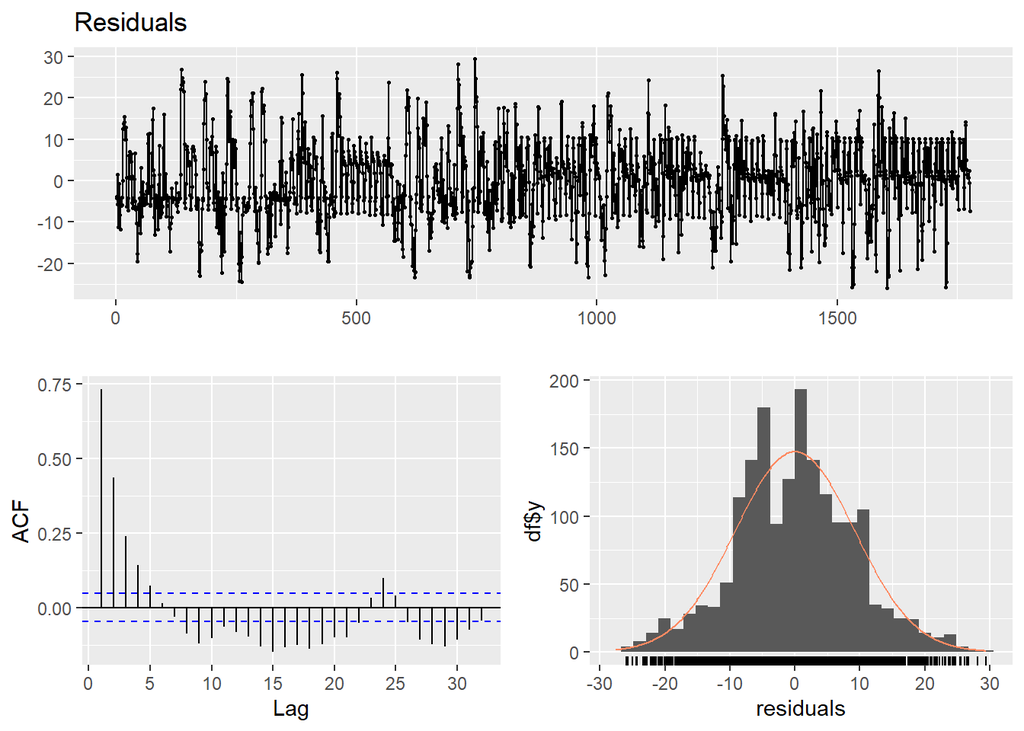

```
##
##  Breusch-Godfrey test for serial correlation of order up to 10
##
## data:  Residuals
## LM test = 1035.5, df = 10, p-value < 2.2e-16
```

```r
checkresiduals(lm2)
```

```r
#############################################

lm3<-lm(production~dswrf+lag12+cloud_low_layer,data = datapn)
summary(lm3)
```

```
##
## Call:
## lm(formula = production ~ dswrf + lag12 + cloud_low_layer, data = datapn)
##
## Residuals:
##     Min      1Q  Median      3Q     Max
## -26.581  -5.979   0.756   5.162  26.971
##
## Coefficients:
##                   Estimate Std. Error t value Pr(>|t|)
## (Intercept)      9.7149406  0.5159630   18.83   <2e-16 ***
## dswrf            0.0084564  0.0007998   10.57   <2e-16 ***
## lag12            0.5099734  0.0169385   30.11   <2e-16 ***
## cloud_low_layer -0.1213295  0.0070599  -17.19   <2e-16 ***
## ---
## Signif. codes:  0 '***' 0.001 '**' 0.01 '*' 0.05 '.' 0.1 ' ' 1
##
## Residual standard error: 8.513 on 1772 degrees of freedom
##   (12 observations deleted due to missingness)
## Multiple R-squared:  0.5954, Adjusted R-squared:  0.5948
## F-statistic: 869.4 on 3 and 1772 DF,  p-value: < 2.2e-16
```

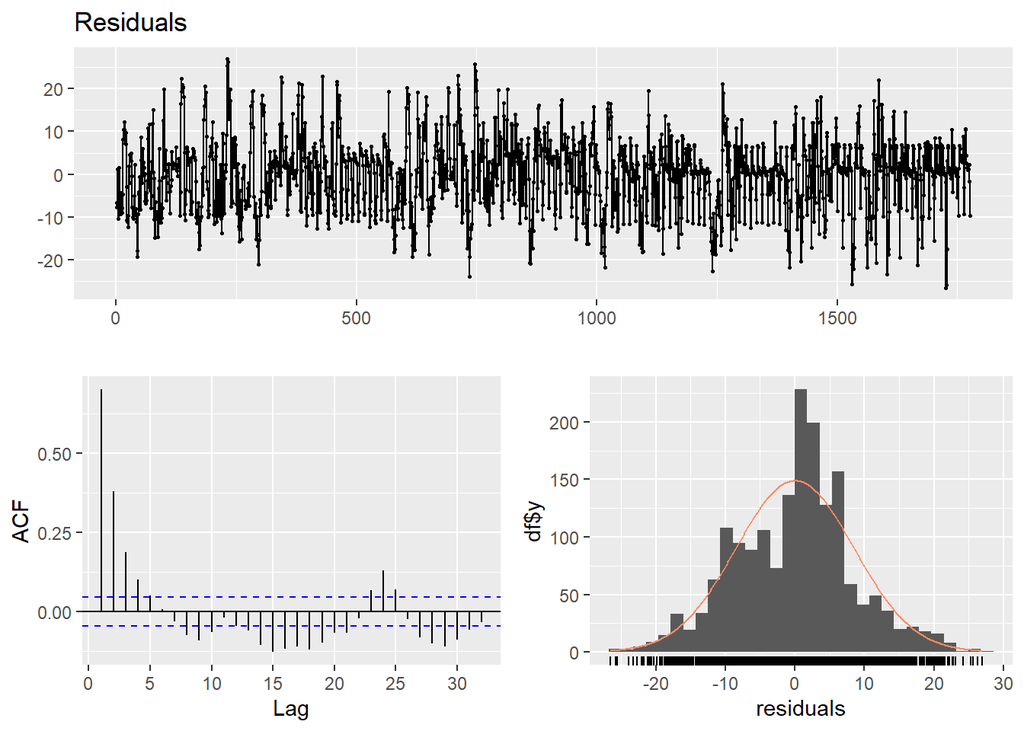

```
##
##  Breusch-Godfrey test for serial correlation of order up to 10
##
## data:  Residuals
## LM test = 970.89, df = 10, p-value < 2.2e-16
```

```r
checkresiduals(lm3)
```

```r
############################################

lm4<-lm(production~dswrf+lag12+cloud_low_layer+lag6+lag1,data = datapn)
summary(lm4)
```

```
##
## Call:
## lm(formula = production ~ dswrf + lag12 + cloud_low_layer + lag6 +
##     lag1, data = datapn)
##
## Residuals:
##     Min      1Q  Median      3Q     Max
## -25.743  -3.903   0.300   3.682  23.577
##
## Coefficients:
##                   Estimate Std. Error t value Pr(>|t|)
## (Intercept)      6.6414261  0.4648586  14.287  < 2e-16 ***
## dswrf           -0.0082888  0.0008343  -9.935  < 2e-16 ***
## lag12            0.3124286  0.0135797  23.007  < 2e-16 ***
## cloud_low_layer -0.0731344  0.0054423 -13.438  < 2e-16 ***
## lag6            -0.0967450  0.0122558  -7.894  5.1e-15 ***
## lag1             0.7031153  0.0200015  35.153  < 2e-16 ***
## ---
## Signif. codes:  0 '***' 0.001 '**' 0.01 '*' 0.05 '.' 0.1 ' ' 1
##
## Residual standard error: 6.27 on 1766 degrees of freedom
##   (16 observations deleted due to missingness)
## Multiple R-squared:  0.7807, Adjusted R-squared:  0.7801
## F-statistic:  1257 on 5 and 1766 DF,  p-value: < 2.2e-16
```

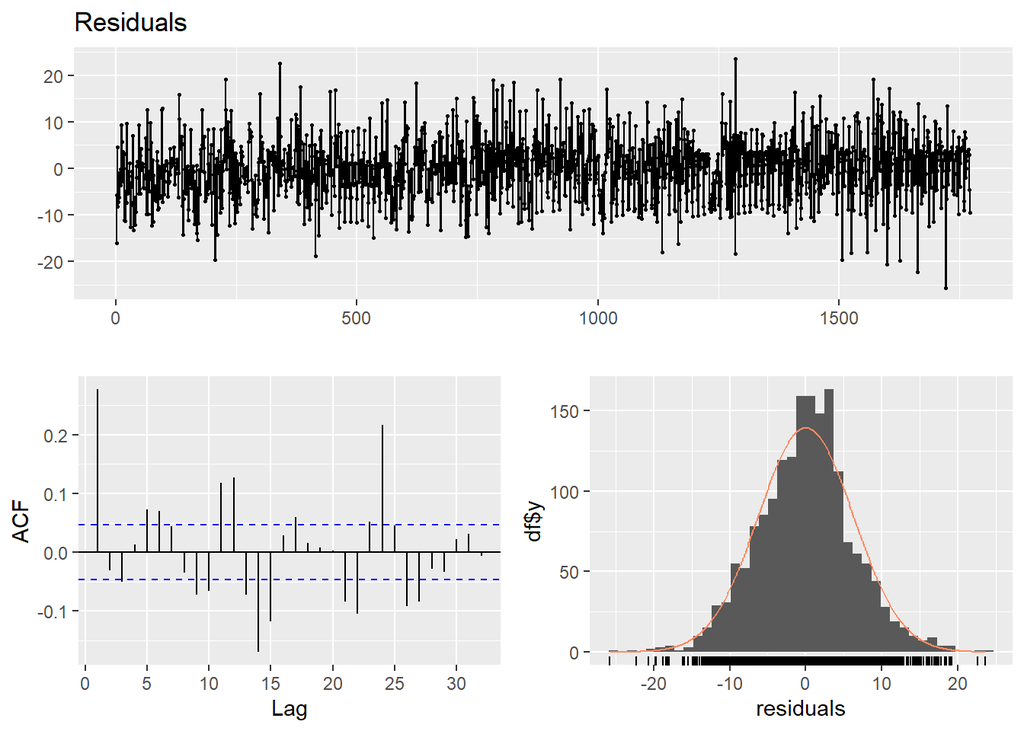

```
##
##  Breusch-Godfrey test for serial correlation of order up to 10
##
## data:  Residuals
## LM test = 267.25, df = 10, p-value < 2.2e-16
```

```r
checkresiduals(lm4)
```

```r
##########################################

lm5<-lm(production~dswrf+lag12+cloud_low_layer+lag1+tmax+tmin+lag6,data = datapn)
summary(lm5)
```

```
##
## Call:
## lm(formula = production ~ dswrf + lag12 + cloud_low_layer + lag1 +
##     tmax + tmin + lag6, data = datapn)
##
## Residuals:
##      Min       1Q   Median       3Q      Max
## -26.0835  -3.8760   0.1997   3.7021  23.1726
##
## Coefficients:
##                   Estimate Std. Error t value Pr(>|t|)
## (Intercept)     -5.6444178  6.0951007  -0.926 0.354542
## dswrf           -0.0084537  0.0008423 -10.037  < 2e-16 ***
## lag12            0.3084106  0.0138345  22.293  < 2e-16 ***
## cloud_low_layer -0.0540529  0.0076024  -7.110 1.68e-12 ***
## lag1             0.6983935  0.0202192  34.541  < 2e-16 ***
## tmax             0.3434131  0.1002944   3.424 0.000631 ***
## tmin            -0.3075478  0.0996476  -3.086 0.002058 **
## lag6            -0.1084508  0.0126969  -8.542  < 2e-16 ***
## ---
## Signif. codes:  0 '***' 0.001 '**' 0.01 '*' 0.05 '.' 0.1 ' ' 1
##
## Residual standard error: 6.25 on 1764 degrees of freedom
##   (16 observations deleted due to missingness)
## Multiple R-squared:  0.7823, Adjusted R-squared:  0.7814
## F-statistic: 905.6 on 7 and 1764 DF,  p-value: < 2.2e-16
```

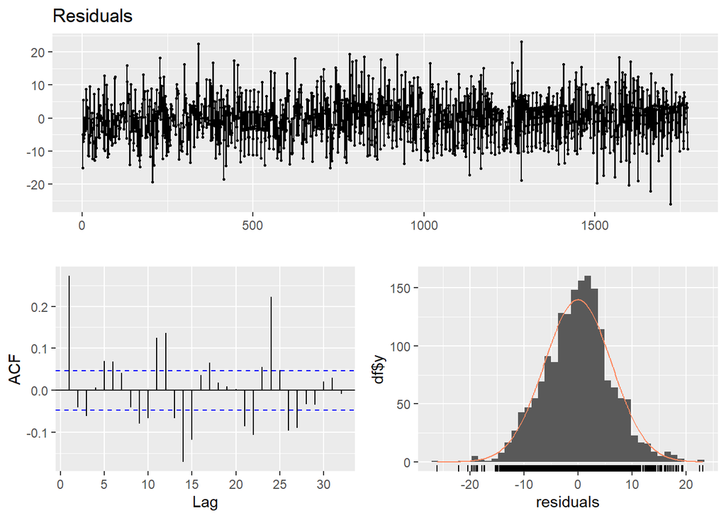

```
##
##  Breusch-Godfrey test for serial correlation of order up to 11
##
## data:  Residuals
## LM test = 283.11, df = 11, p-value < 2.2e-16
```

```r
checkresiduals(lm5)
```

```r
##########################################


lm6<-lm(production~dswrf+lag12+cloud_low_layer+lag1+tmax+hoursoftheday,data = datapn)
summary(lm6)
```

```
##
## Call:
## lm(formula = production ~ dswrf + lag12 + cloud_low_layer + lag1 +
##     tmax + hoursoftheday, data = datapn)
##
## Residuals:
##      Min       1Q   Median       3Q      Max
## -24.4202  -3.5557   0.2408   3.2919  20.6092
##
## Coefficients:
##                  Estimate Std. Error t value Pr(>|t|)
## (Intercept)     -4.948108   5.788475  -0.855 0.392767
## dswrf           -0.002213   0.001082  -2.045 0.041049 *
## lag12            0.118395   0.014730   8.038 1.66e-15 ***
## cloud_low_layer -0.048591   0.005892  -8.246 3.16e-16 ***
## lag1             0.701736   0.018504  37.924  < 2e-16 ***
## tmax             0.039227   0.020269   1.935 0.053110 .
## hoursoftheday8   5.433703   0.656127   8.281 2.38e-16 ***
## hoursoftheday9   4.419822   0.718516   6.151 9.49e-10 ***
## hoursoftheday10  2.161982   0.820953   2.634 0.008525 **
## hoursoftheday11  1.097346   0.861976   1.273 0.203166
## hoursoftheday12  1.010249   0.892216   1.132 0.257666
## hoursoftheday13  1.311446   0.916222   1.431 0.152504
## hoursoftheday14 -0.033029   0.925855  -0.036 0.971546
## hoursoftheday15 -0.949588   0.917998  -1.034 0.301086
## hoursoftheday16 -3.160385   0.854041  -3.701 0.000222 ***
## hoursoftheday17 -8.387063   0.794822 -10.552  < 2e-16 ***
## hoursoftheday18 -9.123782   0.744374 -12.257  < 2e-16 ***
## ---
## Signif. codes:  0 '***' 0.001 '**' 0.01 '*' 0.05 '.' 0.1 ' ' 1
##
## Residual standard error: 5.472 on 1759 degrees of freedom
##   (12 observations deleted due to missingness)
## Multiple R-squared:  0.834,  Adjusted R-squared:  0.8325
## F-statistic: 552.5 on 16 and 1759 DF,  p-value: < 2.2e-16
```

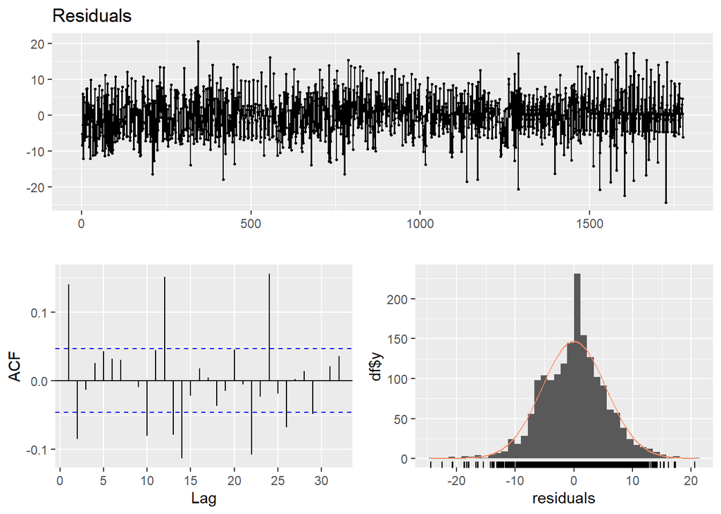

```
##
##  Breusch-Godfrey test for serial correlation of order up to 20
##
## data:  Residuals
## LM test = 183.15, df = 20, p-value < 2.2e-16
```

```r
checkresiduals(lm6)
```

```r
#########################################

lm7<-lm(production~log(dswrf+1)+lag12+log(cloud_low_layer+1)+lag1+tmax+hoursoftheday,data = datapn)
summary(lm7)
```

```
##
## Call:
## lm(formula = production ~ log(dswrf + 1) + lag12 + log(cloud_low_layer +
##     1) + lag1 + tmax + hoursoftheday, data = datapn)
##
## Residuals:
##     Min      1Q  Median      3Q     Max
## -22.124  -3.256   0.397   3.122  17.981
##
## Coefficients:
##                           Estimate Std. Error t value Pr(>|t|)
## (Intercept)               26.77288    5.71546   4.684 3.02e-06 ***
## log(dswrf + 1)             2.88106    0.21134  13.632  < 2e-16 ***
## lag12                      0.05139    0.01488   3.453 0.000568 ***
## log(cloud_low_layer + 1)  -0.63017    0.10617  -5.935 3.52e-09 ***
## lag1                       0.59236    0.01782  33.243  < 2e-16 ***
## tmax                      -0.07952    0.01997  -3.982 7.11e-05 ***
## hoursoftheday8             3.27698    0.64612   5.072 4.36e-07 ***
## hoursoftheday9            -0.09494    0.75333  -0.126 0.899728
## hoursoftheday10           -8.56915    1.01627  -8.432  < 2e-16 ***
## hoursoftheday11          -10.07888    1.04413  -9.653  < 2e-16 ***
## hoursoftheday12          -10.63122    1.06641  -9.969  < 2e-16 ***
## hoursoftheday13          -10.63303    1.08199  -9.827  < 2e-16 ***
## hoursoftheday14          -12.21475    1.09209 -11.185  < 2e-16 ***
## hoursoftheday15          -13.46910    1.10062 -12.238  < 2e-16 ***
## hoursoftheday16          -15.48179    1.08570 -14.260  < 2e-16 ***
## hoursoftheday17          -21.12654    1.09592 -19.277  < 2e-16 ***
## hoursoftheday18          -22.55778    1.12587 -20.036  < 2e-16 ***
## ---
## Signif. codes:  0 '***' 0.001 '**' 0.01 '*' 0.05 '.' 0.1 ' ' 1
##
## Residual standard error: 5.236 on 1759 degrees of freedom
##   (12 observations deleted due to missingness)
## Multiple R-squared:  0.8481, Adjusted R-squared:  0.8467
## F-statistic: 613.7 on 16 and 1759 DF,  p-value: < 2.2e-16
```

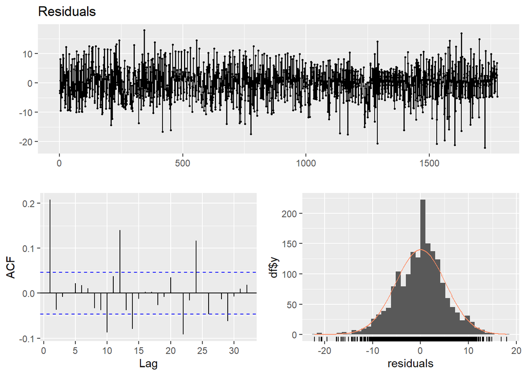

```
##
##  Breusch-Godfrey test for serial correlation of order up to 20
##
## data:  Residuals
## LM test = 227.3, df = 20, p-value < 2.2e-16
```

```r
checkresiduals(lm7)
```

```r
########################################

lm8<-lm(production~log(dswrf+1)+lag12+season+log(cloud_low_layer+1)+lag1+tmax+hoursoftheday,data = datapn)
summary(lm8)
```

```
##
## Call:
## lm(formula = production ~ log(dswrf + 1) + lag12 + season + log(cloud_low_layer +
##     1) + lag1 + tmax + hoursoftheday, data = datapn)
##
## Residuals:
##      Min       1Q   Median       3Q      Max
## -22.1665  -3.2416   0.4233   3.1333  18.0128
##
## Coefficients:
##                           Estimate Std. Error t value Pr(>|t|)
## (Intercept)               23.63565    9.06060   2.609 0.009168 **
## log(dswrf + 1)             2.90097    0.21604  13.428  < 2e-16 ***
## lag12                      0.05169    0.01490   3.469 0.000536 ***
## season2                   -0.24740    0.55433  -0.446 0.655436
## log(cloud_low_layer + 1)  -0.62697    0.10644  -5.891 4.60e-09 ***
## lag1                       0.59269    0.01784  33.224  < 2e-16 ***
## tmax                      -0.06828    0.03213  -2.125 0.033725 *
## hoursoftheday8             3.24861    0.64938   5.003 6.22e-07 ***
## hoursoftheday9            -0.15587    0.76577  -0.204 0.838727
## hoursoftheday10           -8.67642    1.04453  -8.307  < 2e-16 ***
## hoursoftheday11          -10.19113    1.07423  -9.487  < 2e-16 ***
## hoursoftheday12          -10.74657    1.09752  -9.792  < 2e-16 ***
## hoursoftheday13          -10.75046    1.11377  -9.652  < 2e-16 ***
## hoursoftheday14          -12.33291    1.12396 -10.973  < 2e-16 ***
## hoursoftheday15          -13.58647    1.13185 -12.004  < 2e-16 ***
## hoursoftheday16          -15.59354    1.11443 -13.992  < 2e-16 ***
## hoursoftheday17          -21.23067    1.12073 -18.944  < 2e-16 ***
## hoursoftheday18          -22.65190    1.14571 -19.771  < 2e-16 ***
## ---
## Signif. codes:  0 '***' 0.001 '**' 0.01 '*' 0.05 '.' 0.1 ' ' 1
##
## Residual standard error: 5.237 on 1758 degrees of freedom
##   (12 observations deleted due to missingness)
## Multiple R-squared:  0.8481, Adjusted R-squared:  0.8466
## F-statistic: 577.3 on 17 and 1758 DF,  p-value: < 2.2e-16
```

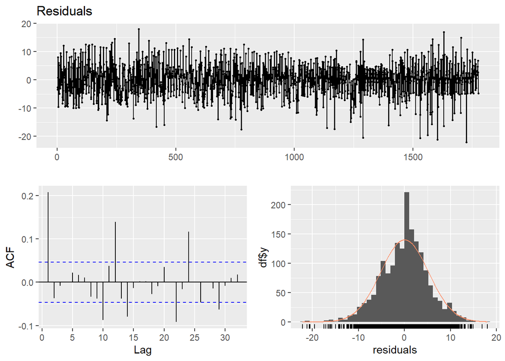

```
##
##  Breusch-Godfrey test for serial correlation of order up to 21
##
## data:  Residuals
## LM test = 228.9, df = 21, p-value < 2.2e-16
```

```r
checkresiduals(lm8)
```

```r
##########################################
lm9<-lm(production~log(dswrf+1)+lag12+season+log(cloud_low_layer+1)+tmax+hoursoftheday+trend+lag1,data = datapn)
summary(lm9)
```

```
##
## Call:
## lm(formula = production ~ log(dswrf + 1) + lag12 + season + log(cloud_low_layer +
##     1) + tmax + hoursoftheday + trend + lag1, data = datapn)
##
## Residuals:
##     Min      1Q  Median      3Q     Max
## -22.207  -3.243   0.414   3.119  18.005
##
## Coefficients:
##                            Estimate Std. Error t value Pr(>|t|)
## (Intercept)               2.477e+01  9.616e+00   2.576 0.010073 *
## log(dswrf + 1)            2.870e+00  2.334e-01  12.295  < 2e-16 ***
## lag12                     5.096e-02  1.505e-02   3.387 0.000723 ***
## season2                  -3.327e-01  6.047e-01  -0.550 0.582278
## log(cloud_low_layer + 1) -6.394e-01  1.121e-01  -5.702 1.38e-08 ***
## tmax                     -7.256e-02  3.434e-02  -2.113 0.034754 *
## hoursoftheday8            3.298e+00  6.646e-01   4.963 7.61e-07 ***
## hoursoftheday9           -4.837e-02  8.242e-01  -0.059 0.953209
## hoursoftheday10          -8.493e+00  1.166e+00  -7.282 4.95e-13 ***
## hoursoftheday11          -9.999e+00  1.205e+00  -8.301  < 2e-16 ***
## hoursoftheday12          -1.055e+01  1.232e+00  -8.560  < 2e-16 ***
## hoursoftheday13          -1.055e+01  1.252e+00  -8.427  < 2e-16 ***
## hoursoftheday14          -1.213e+01  1.263e+00  -9.607  < 2e-16 ***
## hoursoftheday15          -1.339e+01  1.267e+00 -10.565  < 2e-16 ***
## hoursoftheday16          -1.540e+01  1.240e+00 -12.426  < 2e-16 ***
## hoursoftheday17          -2.106e+01  1.225e+00 -17.182  < 2e-16 ***
## hoursoftheday18          -2.250e+01  1.224e+00 -18.378  < 2e-16 ***
## trend                     2.066e-04  5.847e-04   0.353 0.723842
## lag1                      5.917e-01  1.808e-02  32.720  < 2e-16 ***
## ---
## Signif. codes:  0 '***' 0.001 '**' 0.01 '*' 0.05 '.' 0.1 ' ' 1
##
## Residual standard error: 5.238 on 1757 degrees of freedom
##   (12 observations deleted due to missingness)
## Multiple R-squared:  0.8481, Adjusted R-squared:  0.8465
## F-statistic:   545 on 18 and 1757 DF,  p-value: < 2.2e-16
```

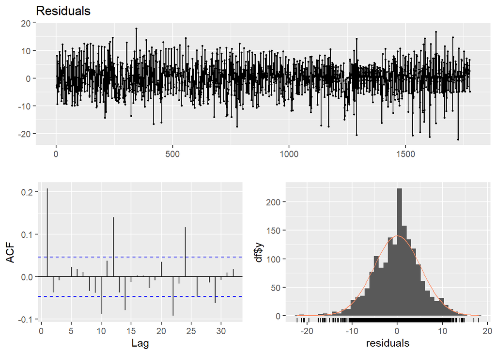

```
##
##  Breusch-Godfrey test for serial correlation of order up to 22
##
## data:  Residuals
## LM test = 253.26, df = 22, p-value < 2.2e-16
```

```r
checkresiduals(lm9)
```

```r
##############################################

lm10<-lm(production~log(dswrf+1)+lag12+season+log(cloud_low_layer+1)+tmax+hoursoftheday+trend+rel_humidity+lag1,data = datapn)
summary(lm10)
```

```
##
## Call:
## lm(formula = production ~ log(dswrf + 1) + lag12 + season + log(cloud_low_layer +
##     1) + tmax + hoursoftheday + trend + rel_humidity + lag1,
##     data = datapn)
##
## Residuals:
##      Min       1Q   Median       3Q      Max
## -22.1201  -3.2677   0.3913   3.1113  17.6154
##
## Coefficients:
##                            Estimate Std. Error t value Pr(>|t|)
## (Intercept)               2.419e+01  9.615e+00   2.516 0.011961 *
## log(dswrf + 1)            2.933e+00  2.358e-01  12.438  < 2e-16 ***
## lag12                     5.164e-02  1.504e-02   3.433 0.000611 ***
## season2                  -1.959e-01  6.090e-01  -0.322 0.747672
## log(cloud_low_layer + 1) -8.055e-01  1.444e-01  -5.579 2.80e-08 ***
## tmax                     -7.667e-02  3.439e-02  -2.229 0.025920 *
## hoursoftheday8            3.272e+00  6.643e-01   4.926 9.17e-07 ***
## hoursoftheday9           -1.230e-01  8.246e-01  -0.149 0.881462
## hoursoftheday10          -8.674e+00  1.170e+00  -7.415 1.88e-13 ***
## hoursoftheday11          -1.014e+01  1.206e+00  -8.407  < 2e-16 ***
## hoursoftheday12          -1.065e+01  1.233e+00  -8.642  < 2e-16 ***
## hoursoftheday13          -1.062e+01  1.252e+00  -8.487  < 2e-16 ***
## hoursoftheday14          -1.219e+01  1.262e+00  -9.655  < 2e-16 ***
## hoursoftheday15          -1.343e+01  1.266e+00 -10.603  < 2e-16 ***
## hoursoftheday16          -1.540e+01  1.239e+00 -12.431  < 2e-16 ***
## hoursoftheday17          -2.107e+01  1.225e+00 -17.202  < 2e-16 ***
## hoursoftheday18          -2.253e+01  1.224e+00 -18.415  < 2e-16 ***
## trend                     5.050e-04  6.067e-04   0.832 0.405381
## rel_humidity              2.561e-02  1.403e-02   1.824 0.068248 .
## lag1                      5.971e-01  1.831e-02  32.607  < 2e-16 ***
## ---
## Signif. codes:  0 '***' 0.001 '**' 0.01 '*' 0.05 '.' 0.1 ' ' 1
##
## Residual standard error: 5.235 on 1756 degrees of freedom
##   (12 observations deleted due to missingness)
## Multiple R-squared:  0.8484, Adjusted R-squared:  0.8467
## F-statistic: 517.2 on 19 and 1756 DF,  p-value: < 2.2e-16
```

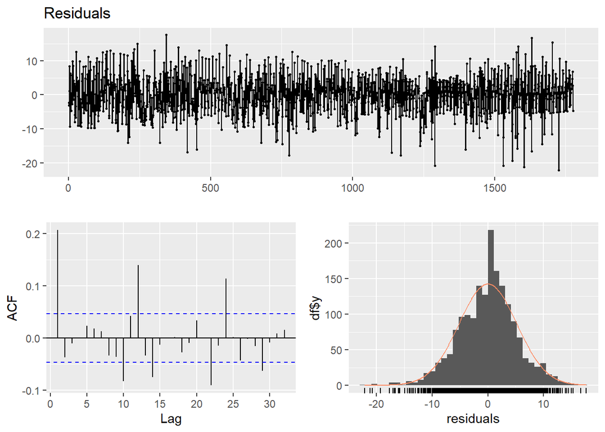

```
##
##  Breusch-Godfrey test for serial correlation of order up to 23
##
## data:  Residuals
## LM test = 253.06, df = 23, p-value < 2.2e-16
```

```r
checkresiduals(lm10)
```

```r
##############################################

lm11<-lm(production~log(dswrf+1)+lag12+season+log(cloud_low_layer+1)+tmax+hoursoftheday+trend+lag2+lag1+lag1dswrf,data = datapn)
summary(lm11)
```

```
##
## Call:
## lm(formula = production ~ log(dswrf + 1) + lag12 + season + log(cloud_low_layer +
##     1) + tmax + hoursoftheday + trend + lag2 + lag1 + lag1dswrf,
##     data = datapn)
##
## Residuals:
##      Min       1Q   Median       3Q      Max
## -22.2359  -3.2179   0.3858   2.9996  19.6070
##
## Coefficients:
##                            Estimate Std. Error t value Pr(>|t|)
## (Intercept)               2.986e+01  9.704e+00   3.078  0.00212 **
## log(dswrf + 1)            2.848e+00  2.301e-01  12.374  < 2e-16 ***
## lag12                     4.387e-02  1.491e-02   2.943  0.00330 **
## season2                  -4.285e-01  5.967e-01  -0.718  0.47286
## log(cloud_low_layer + 1) -7.841e-01  1.184e-01  -6.621 4.74e-11 ***
## tmax                     -8.644e-02  3.448e-02  -2.507  0.01228 *
## hoursoftheday8            1.789e+00  7.585e-01   2.358  0.01849 *
## hoursoftheday9           -1.795e+00  8.947e-01  -2.007  0.04495 *
## hoursoftheday10          -9.236e+00  1.184e+00  -7.802 1.03e-14 ***
## hoursoftheday11          -1.019e+01  1.192e+00  -8.552  < 2e-16 ***
## hoursoftheday12          -1.047e+01  1.229e+00  -8.521  < 2e-16 ***
## hoursoftheday13          -1.046e+01  1.261e+00  -8.298  < 2e-16 ***
## hoursoftheday14          -1.211e+01  1.282e+00  -9.447  < 2e-16 ***
## hoursoftheday15          -1.319e+01  1.292e+00 -10.206  < 2e-16 ***
## hoursoftheday16          -1.519e+01  1.268e+00 -11.982  < 2e-16 ***
## hoursoftheday17          -2.065e+01  1.225e+00 -16.857  < 2e-16 ***
## hoursoftheday18          -2.174e+01  1.216e+00 -17.883  < 2e-16 ***
## trend                     6.232e-04  6.584e-04   0.946  0.34404
## lag2                     -1.780e-01  2.354e-02  -7.561 6.43e-14 ***
## lag1                      7.116e-01  2.369e-02  30.044  < 2e-16 ***
## lag1dswrf                 1.258e-03  1.159e-03   1.086  0.27758
## ---
## Signif. codes:  0 '***' 0.001 '**' 0.01 '*' 0.05 '.' 0.1 ' ' 1
##
## Residual standard error: 5.156 on 1755 degrees of freedom
##   (12 observations deleted due to missingness)
## Multiple R-squared:  0.853,  Adjusted R-squared:  0.8514
## F-statistic: 509.3 on 20 and 1755 DF,  p-value: < 2.2e-16
```

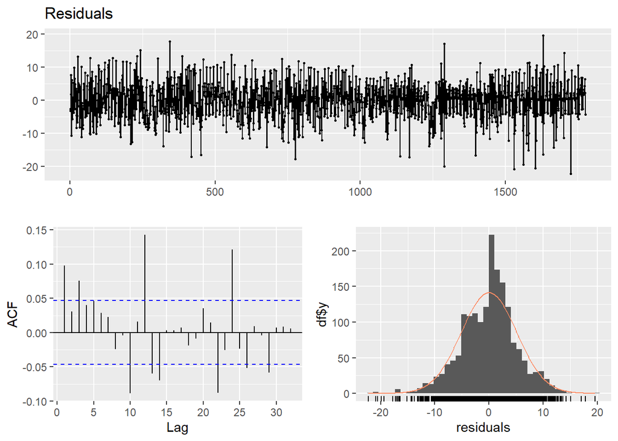

```
##
##  Breusch-Godfrey test for serial correlation of order up to 24
##
## data:  Residuals
## LM test = 240.62, df = 24, p-value < 2.2e-16
```

```r
checkresiduals(lm11)
```

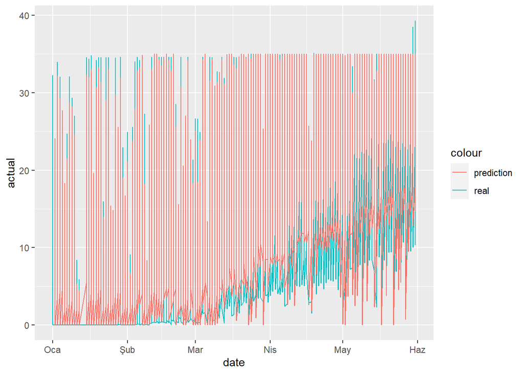

```r
############################################
tmp=copy(datapn)
predicted<-predict(lm11,tmp)
tmp$actual<-tmp$production
tmp$predicted<-predicted
tmp$predicted[tmp$predicted>=35]=35
tmp$predicted[tmp$predicted<=0]=0
ggplot(tmp,aes(x=date))+geom_line(aes(y=actual,color='real'))+geom_line(aes(y=predicted,color='prediction'))
```

```r
#head(tmp,35)
#tail(tmp,25)

########################?###################

lm12<-lm(production~log(dswrf+1)+lag12+season+log(cloud_low_layer+1)+tmax+hoursoftheday+lag2+lag1+lag1dswrf,data = datapn)
summary(lm12)
```

```
##
## Call:
## lm(formula = production ~ log(dswrf + 1) + lag12 + season + log(cloud_low_layer +
##     1) + tmax + hoursoftheday + lag2 + lag1 + lag1dswrf, data = datapn)
##
## Residuals:
##     Min      1Q  Median      3Q     Max
## -22.178  -3.230   0.443   2.968  19.634
##
## Coefficients:
##                            Estimate Std. Error t value Pr(>|t|)
## (Intercept)               26.271446   8.930186   2.942  0.00331 **
## log(dswrf + 1)             2.925801   0.214788  13.622  < 2e-16 ***
## lag12                      0.046282   0.014690   3.151  0.00166 **
## season2                   -0.249711   0.566052  -0.441  0.65916
## log(cloud_low_layer + 1)  -0.736463   0.107201  -6.870 8.89e-12 ***
## tmax                      -0.073462   0.031639  -2.322  0.02035 *
## hoursoftheday8             1.839228   0.756628   2.431  0.01516 *
## hoursoftheday9            -1.888541   0.889183  -2.124  0.03382 *
## hoursoftheday10           -9.526877   1.142973  -8.335  < 2e-16 ***
## hoursoftheday11          -10.685215   1.070807  -9.979  < 2e-16 ***
## hoursoftheday12          -11.017573   1.084885 -10.156  < 2e-16 ***
## hoursoftheday13          -11.049970   1.097680 -10.067  < 2e-16 ***
## hoursoftheday14          -12.724749   1.107631 -11.488  < 2e-16 ***
## hoursoftheday15          -13.804595   1.114869 -12.382  < 2e-16 ***
## hoursoftheday16          -15.792854   1.098298 -14.379  < 2e-16 ***
## hoursoftheday17          -21.154216   1.104452 -19.154  < 2e-16 ***
## hoursoftheday18          -22.160378   1.133178 -19.556  < 2e-16 ***
## lag2                      -0.178028   0.023541  -7.562 6.35e-14 ***
## lag1                       0.712757   0.023657  30.128  < 2e-16 ***
## lag1dswrf                  0.001765   0.001027   1.719  0.08582 .
## ---
## Signif. codes:  0 '***' 0.001 '**' 0.01 '*' 0.05 '.' 0.1 ' ' 1
##
## Residual standard error: 5.155 on 1756 degrees of freedom
##   (12 observations deleted due to missingness)
## Multiple R-squared:  0.853,  Adjusted R-squared:  0.8514
## F-statistic: 536.1 on 19 and 1756 DF,  p-value: < 2.2e-16
```

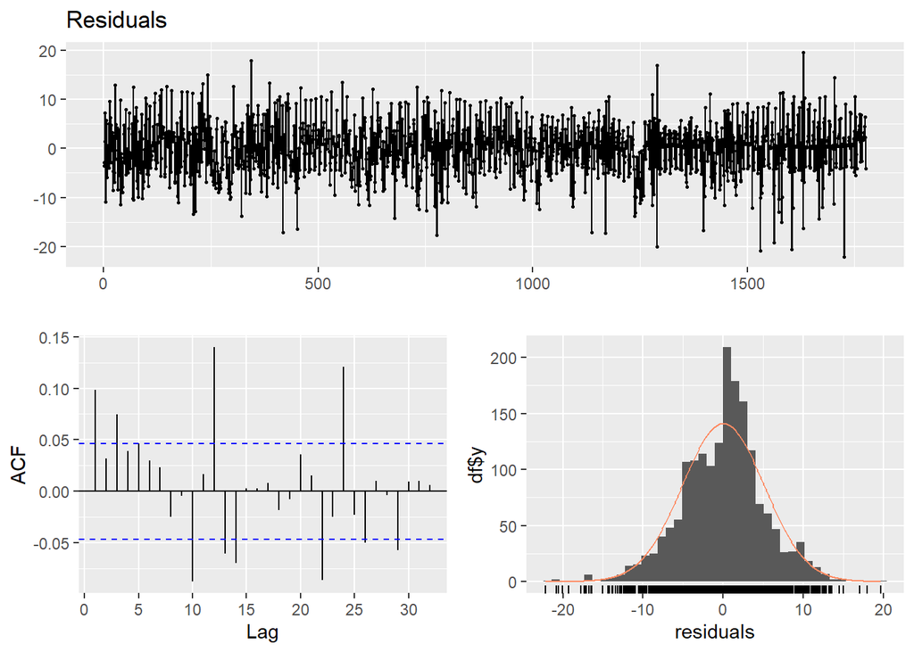

```
##
##  Breusch-Godfrey test for serial correlation of order up to 23
##
## data:  Residuals
## LM test = 229.25, df = 23, p-value < 2.2e-16
```

```r
checkresiduals(lm12)
```

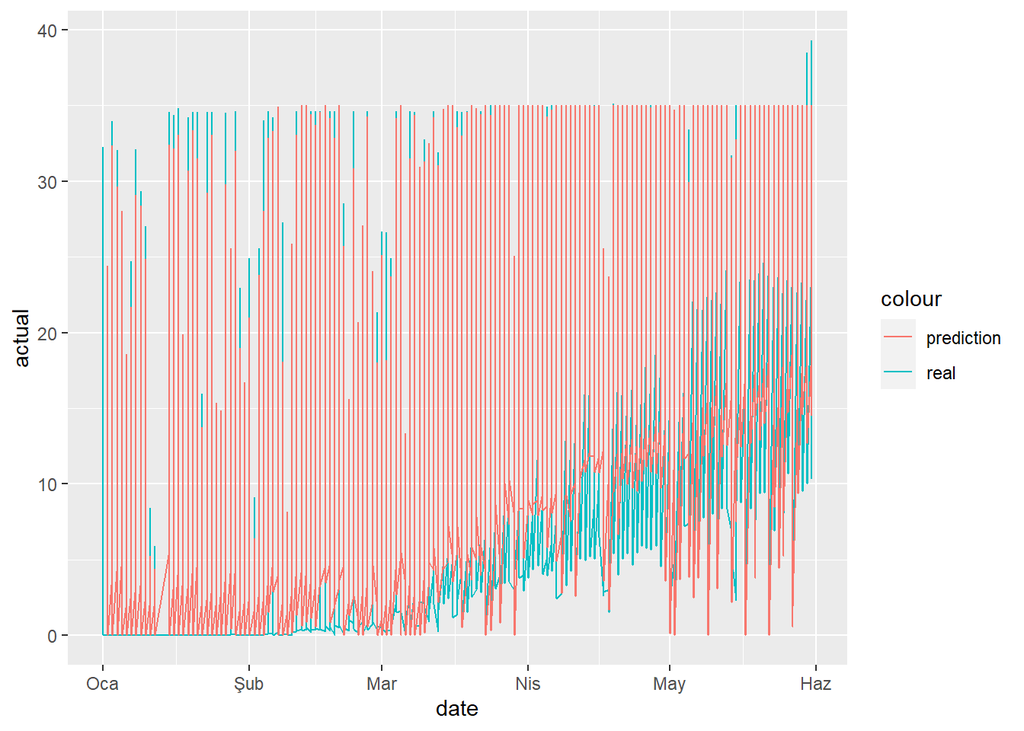

```r
##################################?##########
tmp2=copy(datapn)
predicted<-predict(lm12,tmp)
#predicted
tmp2$actual<-tmp$production
tmp2$predicted<-predicted
tmp2$predicted[tmp2$predicted>=35]=35
tmp2$predicted[tmp2$predicted<=0]=0
ggplot(tmp2,aes(x=date))+geom_line(aes(y=actual,color='real'))+geom_line(aes(y=predicted,color='prediction'))
```

```r
#head(tmp2,35)
#tail(tmp2,25)
```

In this approach, it can be seen from the summary tables, especially from adjusted R^2 square values, and plots that by adding new parameters, such as lags, seasonality and trend we tried to make better model at each iteration.

# 3.3.2 Regression Approach based on hour-by-hour Production Amount

```r
datawDegerler<-reshape(dataw,idvar=c("date","hour","lat","lon"),timevar="variable",direction = "wide",v.names="value")
#head(datawDegerler,10)

#esas data is coming
DT2 <- data.table(datawDegerler)
DTmean2<-DT2[, mean(value.TEMP), by = datetime, ]
DTmean22<-DT2[, mean(value.DSWRF), by = datetime]
DTmean32<-DT2[, mean(value.CLOUD_LOW_LAYER), by = datetime]
DTmean42<-DT2[, mean(value.REL_HUMIDITY), by = datetime]
data12<-merge(DTmean2,DTmean22,by="datetime")
data22<-merge(data12,DTmean32,by="datetime")
data2<-merge(data22,DTmean42,by="datetime")
colnames(data2)<-c("datetime","temp","dswrf","cloud_low_layer","rel_humidity")
```

t=06.00 am:

```r
lag1<-shift(dataph6$production, n=1L, fill=NA)
dataph6$lag1<-lag1
dataph6$season<-as.factor(quarter(dataph6$date))
modelh6<-lm(production~dswrf+temp+lag1+season,data=dataph6)
summary(modelh6)
```

```
##
## Call:
## lm(formula = production ~ dswrf + temp + lag1 + season, data = dataph6)
##
## Residuals:
##     Min      1Q  Median      3Q     Max
## -4.1157 -0.1636 -0.0005  0.0988  3.5563
##
## Coefficients:
##             Estimate Std. Error t value Pr(>|t|)
## (Intercept)  5.38272    4.38506   1.228    0.222
## dswrf        1.41752    0.27236   5.205 6.63e-07 ***
## temp        -0.01964    0.01602  -1.226    0.222
## lag1         0.57362    0.07017   8.175 1.44e-13 ***
## season2      1.04191    0.24503   4.252 3.80e-05 ***
## ---
## Signif. codes:  0 '***' 0.001 '**' 0.01 '*' 0.05 '.' 0.1 ' ' 1
##
## Residual standard error: 0.7423 on 143 degrees of freedom
##   (1 observation deleted due to missingness)
## Multiple R-squared:  0.8976, Adjusted R-squared:  0.8948
## F-statistic: 313.5 on 4 and 143 DF,  p-value: < 2.2e-16
```

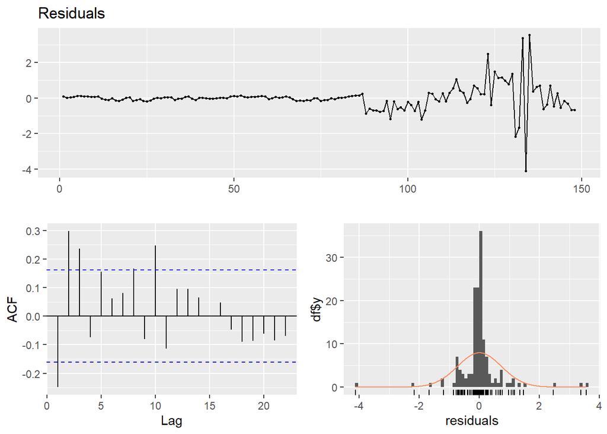

```
##
##  Breusch-Godfrey test for serial correlation of order up to 10
##
## data:  Residuals
## LM test = 51.646, df = 10, p-value = 1.327e-07
```

```r
checkresiduals(modelh6)
```

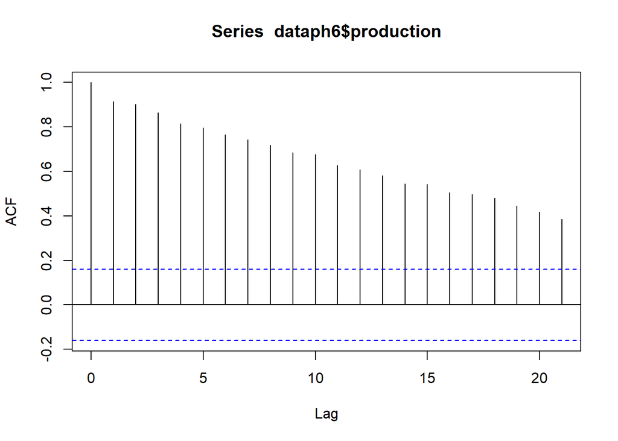

```r
acf(dataph6$production)
```

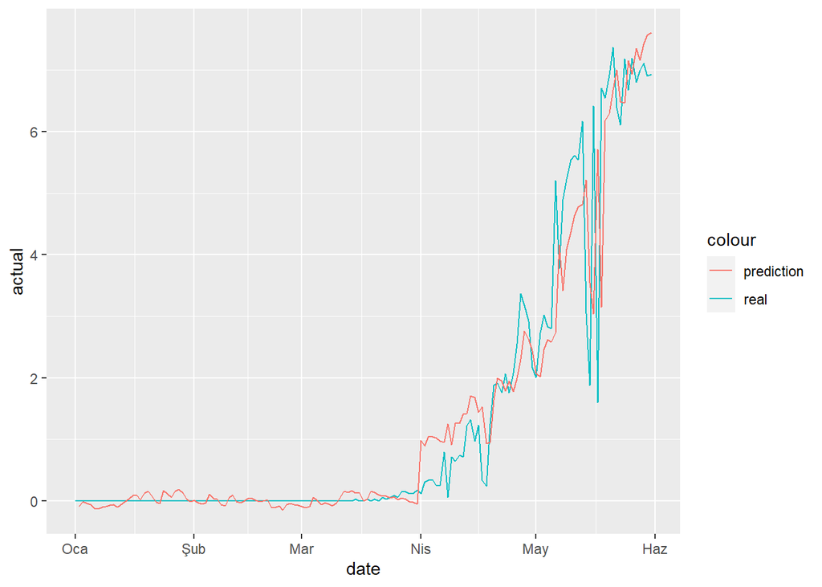

```r
tmp=copy(dataph6)
predicted<-predict(modelh6,tmp)
tmp$actual<-tmp$production
#rmse(tmp$actual, tmp$predicted,na.rm=TRUE)
ggplot(tmp,aes(x=date))+geom_line(aes(y=actual,color='real'))+geom_line(aes(y=predicted,color='prediction'))
```

to predict new day’s production by using previous data:

```r
test<-dataph6[142,]
test$datetime=="2022-05-24 09:00:00"
```

```
## [1] TRUE
```

```r
test$date=as.Date("2022-05-24")
test$temp=287.1000
test$dswrf=1.535556
test$cloud_low_layer=8.02222222
test$rel_humidity=57.97778
test$hour=6
test$lag1=6.11
test$season=as.factor(quarter(test$date))
tmp<-rbindlist(list(tmp,test),fill=T,use.names=T)

#tail(tmp,15)
#mp<-tmp[-141,]


#tail(tmp,15)
predicted<-predict(modelh6,tmp)
tmp$predicted<-predicted

tmp[is.na(production),production:=predicted]


#tail(tmp,15)

test$datetime=="2022-05-25 06:00:00"
```

```
## [1] FALSE
```

```r
test$date=as.Date("2022-05-25")
test$temp=288.8556
test$dswrf=1.595556
test$cloud_low_layer=0.00000000
test$rel_humidity=43.98889
test$hour=6
test$lag1= 7.048636
test$season=as.factor(quarter(test$date))
tmp<-rbindlist(list(tmp,test),fill=T,use.names=T)
#tail(tmp,15)

predicted<-predict(modelh6,tmp)
tmp$predicted<-predicted

#tail(tmp,15)


tmp[is.na(production),production:=predicted]

test$datetime=="2022-05-25 06:00:00"
```

```
## [1] FALSE
```

```r
test$date=as.Date("2022-05-26")
test$temp= 290.0808
test$dswrf=1.667556
test$cloud_low_layer=0.00000000
test$rel_humidity=54.47778
test$hour=6
test$lag1=7.636677
test$season=as.factor(quarter(test$date))
tmp<-rbindlist(list(tmp,test),fill=T,use.names=T)
#tail(tmp,15)

predicted<-predict(modelh6,tmp)
tmp$predicted<-predicted

tail(tmp,15)
```

```
##                datetime     temp    dswrf cloud_low_layer rel_humidity
##  1: 2022-05-20 06:00:00 281.7907 1.160889       1.9222222     67.44444
##  2: 2022-05-21 06:00:00 283.8242 1.312000       0.0000000     43.64444
##  3: 2022-05-22 06:00:00 288.3654 1.422222       0.0000000     32.90000
##  4: 2022-05-23 06:00:00 286.5150 1.424444       1.7888889     61.37778
##  5: 2022-05-24 06:00:00 287.1000 1.535556       8.0222222     57.97778
##  6: 2022-05-25 06:00:00 288.3162 1.600000       0.0000000     44.92222
##  7: 2022-05-26 06:00:00 289.5858 1.671111       0.0000000     58.33333
##  8: 2022-05-27 06:00:00 291.4353 1.782222       0.0000000     43.74444
##  9: 2022-05-28 06:00:00 291.5327 1.808889       0.1888889     47.92222
## 10: 2022-05-29 06:00:00 292.7034 1.931111       0.0000000     43.85556
## 11: 2022-05-30 06:00:00 293.1711 1.988889       0.0000000     44.70000
## 12: 2022-05-31 06:00:00 292.8922 2.100000       0.0000000     33.84444
## 13: 2022-05-24 06:00:00 287.1000 1.535556       8.0222222     57.97778
## 14: 2022-05-24 06:00:00 288.8556 1.595556       0.0000000     43.98889
```

[output cut: 17 more lines]

```r
data2[datetime=="2022-05-27 10:00:00"]
```

```
##               datetime     temp    dswrf cloud_low_layer rel_humidity
## 1: 2022-05-27 07:00:00 293.0224 29.89156               0     42.81111
```

t=07.00 am:

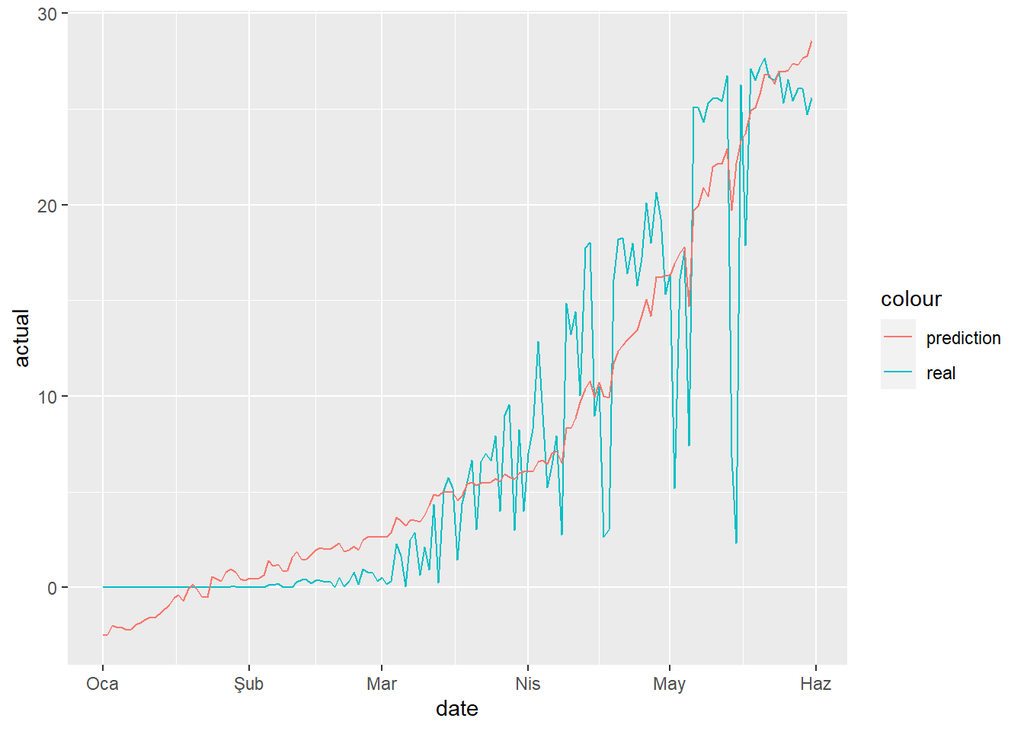

```r
dataph7[,trend:=1:.N]
lag1<-shift(dataph7$production, n=1L, fill=NA)
dataph7$lag1<-lag1

modelh7<-lm(production~dswrf+temp+trend,data=dataph7)
tmp=copy(dataph7)
predicted<-predict(modelh7,tmp)
tmp$actual<-tmp$production
#rmse(tmp$actual, tmp$predicted,na.rm=TRUE)
#data2[datetime=="2022-06-01 10:00:00"]
ggplot(tmp,aes(x=date))+geom_line(aes(y=actual,color='real'))+geom_line(aes(y=predicted,color='prediction'))
```

```r
test<-dataph7[146,]



tmp[is.na(production),production:=predicted]

test$datetime=="2022-05-28 07:00:00"
test$date=as.Date("2022-05-28")
test$temp= 295.5739
test$dswrf=29.62
test$cloud_low_layer= 0.1444444
test$rel_humidity=38.6
test$hour=7
test$trend=146
test$lag1=25.45
tmp<-rbindlist(list(tmp,test),fill=T,use.names=T)
tail(tmp,15)
predicted<-predict(modelh7,tmp)
tmp$predicted<-predicted

tail(tmp,15)
tmp[is.na(production),production:=predicted]

test$datetime=="2022-05-29 07:00:00"
test$date=as.Date("2022-05-29")
test$temp= 295.5257
test$dswrf=30.42444
test$cloud_low_layer= 0
test$rel_humidity=38.63333
test$hour=7
test$trend=147
test$lag1=25.45
tmp<-rbindlist(list(tmp,test),fill=T,use.names=T)
tail(tmp,15)
predicted<-predict(modelh7,tmp)
tmp$predicted<-predicted

tail(tmp,15)

tmp[is.na(production),production:=predicted]

test$datetime=="2022-05-30 07:00:00"
test$date=as.Date("2022-05-30")
test$temp= 296.555
test$dswrf=30.60089
test$cloud_low_layer= 0
test$rel_humidity=37.91111
test$hour=7
test$trend=148
test$lag1=25.45
tmp<-rbindlist(list(tmp,test),fill=T,use.names=T)
tail(tmp,15)
predicted<-predict(modelh7,tmp)
tmp$predicted<-predicted

tail(tmp,15)
```

t=08.00 am:

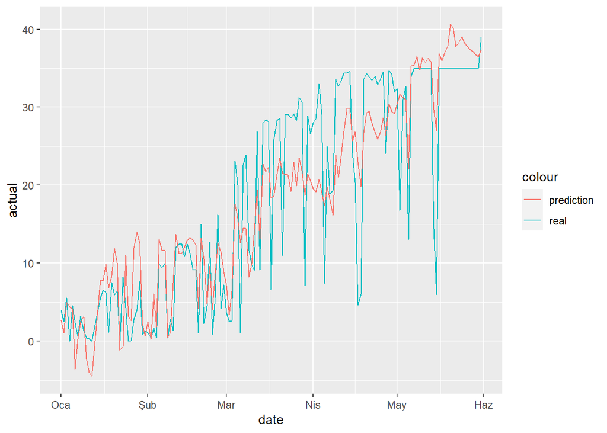

```r
dataph8[,trend:=1:.N]

modelh8<-lm(production~dswrf+temp+trend+(cloud_low_layer)^2,data=dataph8)
tmp=copy(dataph8)
predicted<-predict(modelh8,tmp)
tmp$actual<-tmp$production
#rmse(tmp$actual, tmp$predicted,na.rm=TRUE)

#data2[datetime=="2022-05-30 11:00:00"]
ggplot(tmp,aes(x=date))+geom_line(aes(y=actual,color='real'))+geom_line(aes(y=predicted,color='prediction'))
```

```r
test<-dataph8[146,]


tmp[is.na(production),production:=predicted]


tail(tmp,15)
tail(tmp,15)
test$datetime=="2022-05-28 08:00:00"
test$date=as.Date("2022-05-28")
test$temp=295.5739
test$dswrf=85.33156
test$cloud_low_layer=   0.1444444
test$rel_humidity=38.6
test$hour=8
test$trend=146

tmp<-rbindlist(list(tmp,test),fill=T,use.names=T)

tail(tmp,15)
predicted<-predict(modelh8,tmp)
tmp$predicted<-predicted




tail(tmp,15)
tmp[is.na(production),production:=predicted]



tail(tmp,15)
tail(tmp,15)
test$datetime=="2022-05-29 08:00:00"
test$date=as.Date("2022-05-29")
test$temp=297.3778
test$dswrf=87.00622
test$cloud_low_layer=   0
test$rel_humidity=32.16667
test$hour=8
test$trend=147

tmp<-rbindlist(list(tmp,test),fill=T,use.names=T)

tail(tmp,15)
predicted<-predict(modelh8,tmp)
tmp$predicted<-predicted


tail(tmp,15)
tmp[is.na(production),production:=predicted]


tail(tmp,15)
tail(tmp,15)
test$datetime=="2022-05-30 08:00:00"
test$date=as.Date("2022-05-30")
test$temp=298.1397
test$dswrf=87.13422
test$cloud_low_layer=   0
test$rel_humidity=32.32222
test$hour=8
test$trend=148

tmp<-rbindlist(list(tmp,test),fill=T,use.names=T)

tail(tmp,15)
predicted<-predict(modelh8,tmp)
tmp$predicted<-predicted

tmp[is.na(production),production:=predicted]
tmp$predicted[tmp$predicted>=35]=35


tail(tmp,15)
```

t=09.00 am:

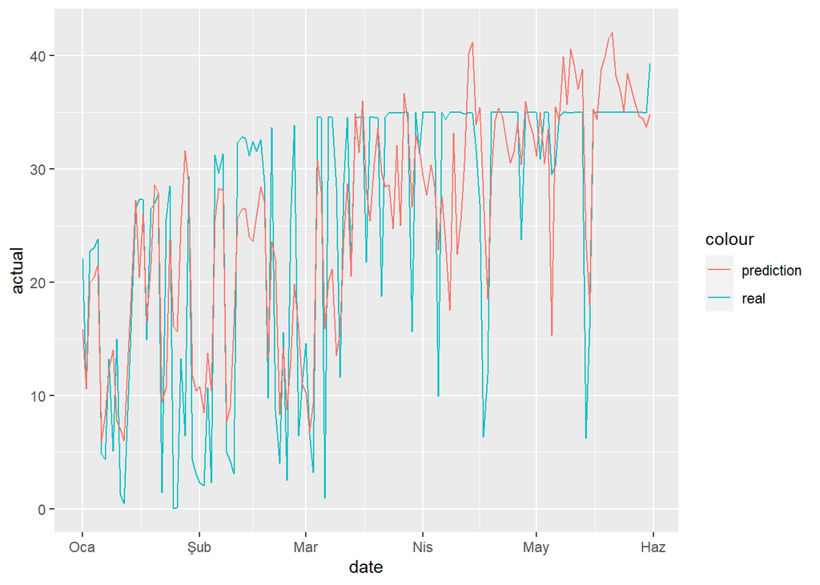

```r
dataph9[,trend:=1:.N]

modelh9<-lm(production~dswrf+temp+log(cloud_low_layer+1)+trend,data=dataph9)
tmp=copy(dataph9)
predicted<-predict(modelh9,tmp)
tmp$actual<-tmp$production
#rmse(tmp$actual, tmp$predicted,na.rm=TRUE)
#data2[datetime=="2022-05-30 12:00:00"]
ggplot(tmp,aes(x=date))+geom_line(aes(y=actual,color='real'))+geom_line(aes(y=predicted,color='prediction'))
```

```r
test<-dataph9[146,]

tmp[is.na(production),production:=predicted]

test$datetime=="2022-05-28 09:00:00"
test$date=as.Date("2022-05-28")
test$temp=297.0332
test$dswrf=157.0436
test$cloud_low_layer=0.3
test$rel_humidity=33.57778
test$hour=9
test$trend=146



tmp<-rbindlist(list(tmp,test),fill=T,use.names=T)
#tail(tmp,15)

predicted<-as.numeric(predict(modelh9,tmp))
tmp$predicted<-predicted


#tail(tmp,15)


tmp[is.na(production),production:=predicted]

test$datetime=="2022-05-29 09:00:00"
test$date=as.Date("2022-05-29")
test$temp=298.6696
test$dswrf=158.96
test$cloud_low_layer= 0
test$rel_humidity=29.81111
test$hour=9
test$trend=147
tmp<-rbindlist(list(tmp,test),fill=T,use.names=T)


predicted<-predict(modelh9,tmp)
tmp$predicted<-predicted
tmp$predicted[tmp$predicted>=35]=35

#tail(tmp,15)

test$datetime=="2022-05-30 09:00:00"
test$date=as.Date("2022-05-30")
test$temp=299.4428
test$dswrf=158.9796
test$cloud_low_layer=0
test$rel_humidity=29.95556
test$hour=9
test$trend=148

tmp<-rbindlist(list(tmp,test),fill=T,use.names=T)

predicted<-predict(modelh9,tmp)
tmp$predicted<-predicted
tmp$predicted[tmp$predicted>=35]=35

tmp[is.na(production),production:=predicted]


#tail(tmp,15)
```

t=10.00 am:

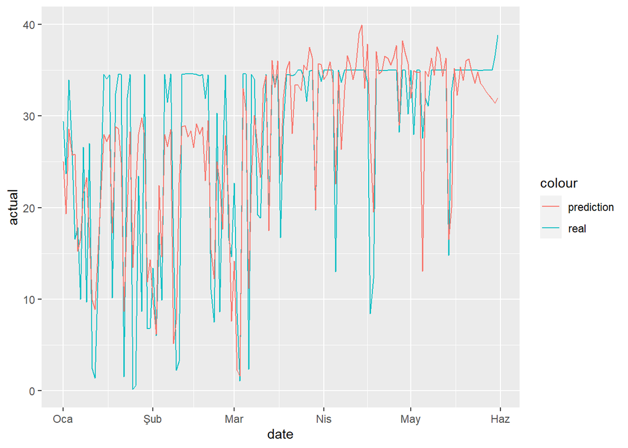

```r
dataph10[,trend:=1:.N]

modelh10<-lm(production~dswrf+log(cloud_low_layer+1)+temp+trend,data=dataph10)
tmp=copy(dataph10)
predicted<-predict(modelh10,tmp)
tmp$actual<-tmp$production
#rmse(tmp$actual, tmp$predicted,na.rm=TRUE)
#data2[datetime=="2022-05-30 13:00:00"]
ggplot(tmp,aes(x=date))+geom_line(aes(y=actual,color='real'))+geom_line(aes(y=predicted,color='prediction'))
```

```r
test<-dataph10[146,]

tmp[is.na(production),production:=predicted]

test$datetime=="2022-05-28 10:00:00"
test$date=as.Date("2022-05-28")
test$temp=298.4259
test$dswrf=704.4044
test$cloud_low_layer=0
test$rel_humidity=29.41111
test$hour=10
test$trend=146



tmp<-rbindlist(list(tmp,test),fill=T,use.names=T)
tail(tmp,15)

predicted<-as.numeric(predict(modelh10,tmp))
tmp$predicted<-predicted


#tail(tmp,15)


tmp[is.na(production),production:=predicted]

test$datetime=="2022-05-29 10:00:00"
test$date=as.Date("2022-05-29")
test$temp=299.703
test$dswrf=705.2933
test$cloud_low_layer= 0
test$rel_humidity=28.51111
test$hour=10
test$trend=147
tmp<-rbindlist(list(tmp,test),fill=T,use.names=T)


predicted<-predict(modelh10,tmp)
tmp$predicted<-predicted
tmp$predicted[tmp$predicted>=35]=35

#tail(tmp,15)

test$datetime=="2022-05-30 10:00:00"
test$date=as.Date("2022-05-30")
test$temp=300.61
test$dswrf=704.9311
test$cloud_low_layer=0
test$rel_humidity=28.2

test$hour=10
test$trend=148

tmp<-rbindlist(list(tmp,test),fill=T,use.names=T)

predicted<-predict(modelh10,tmp)
tmp$predicted<-predicted
tmp$predicted[tmp$predicted>=35]=35

tmp[is.na(production),production:=predicted]


#tail(tmp,15)
```

t=11.00 am:

```r
dataph11[,trend:=1:.N]

modelh11<-lm(production~dswrf+temp+trend,data=dataph11)
tmp=copy(dataph11)
predicted<-predict(modelh11,tmp)
tmp$actual<-tmp$production
#rmse(tmp$actual, tmp$predicted,na.rm=TRUE)
data2[datetime=="2022-05-30 19:00:00"]
```

```
##               datetime     temp    dswrf cloud_low_layer rel_humidity
## 1: 2022-05-30 16:00:00 303.2444 748.0667               0     22.34444
```

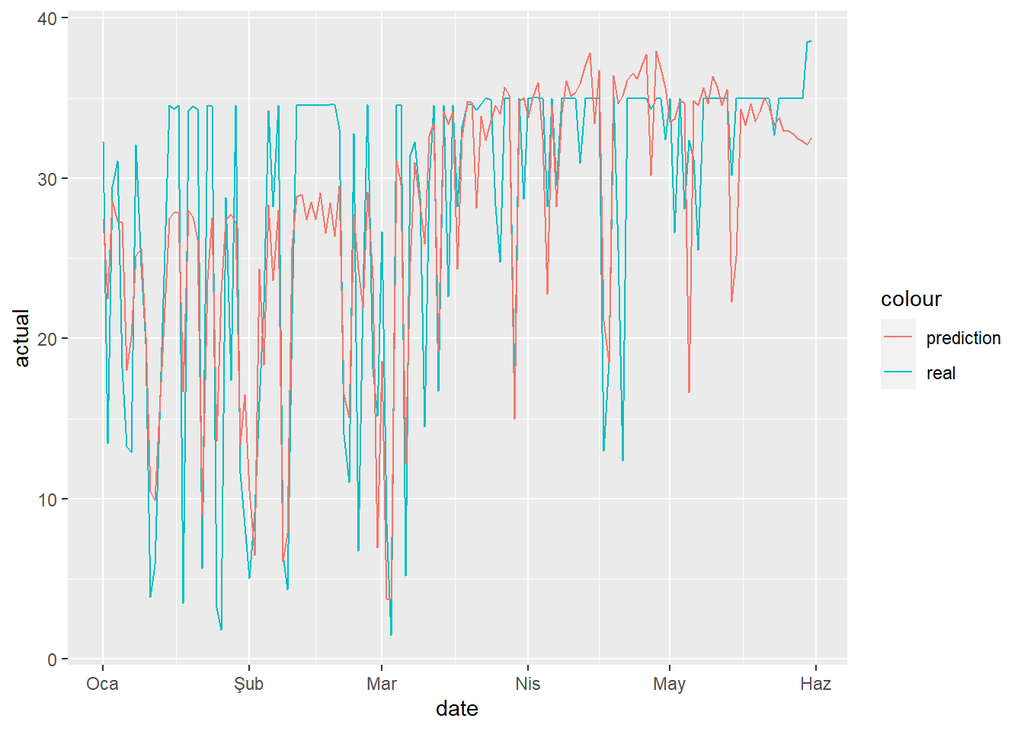

```r
ggplot(tmp,aes(x=date))+geom_line(aes(y=actual,color='real'))+geom_line(aes(y=predicted,color='prediction'))
```

```r
test<-dataph11[146,]

tmp[is.na(production),production:=predicted]

test$datetime=="2022-05-28 11:00:00"
test$date=as.Date("2022-05-28")
test$temp=299.4056
test$dswrf=780.2378
test$cloud_low_layer=0
test$rel_humidity=27.28889
test$hour=11
test$trend=146



tmp<-rbindlist(list(tmp,test),fill=T,use.names=T)
tail(tmp,15)

predicted<-as.numeric(predict(modelh11,tmp))
tmp$predicted<-predicted


tail(tmp,15)


tmp[is.na(production),production:=predicted]

test$datetime=="2022-05-29 11:00:00"
test$date=as.Date("2022-05-29")
test$temp=300.625
test$dswrf=779.8978
test$cloud_low_layer= 0
test$rel_humidity=27.42222
test$hour=11
test$trend=147
tmp<-rbindlist(list(tmp,test),fill=T,use.names=T)


predicted<-predict(modelh11,tmp)
tmp$predicted<-predicted
tmp$predicted[tmp$predicted>=35]=35

tail(tmp,15)

test$datetime=="2022-05-30 11:00:00"
test$date=as.Date("2022-05-30")
test$temp=301.6403
test$dswrf=779.9978
test$cloud_low_layer=0
test$rel_humidity=26.55556


test$hour=11
test$trend=148

tmp<-rbindlist(list(tmp,test),fill=T,use.names=T)

predicted<-predict(modelh11,tmp)
tmp$predicted<-predicted
tmp$predicted[tmp$predicted>=35]=35

tmp[is.na(production),production:=predicted]


tail(tmp,15)
```

t=12.00 pm :

```r
dataph12[,trend:=1:.N]
modelh12<-lm(production~dswrf+temp+log(cloud_low_layer+1)+trend,data=dataph12)
tmp=copy(dataph12)
predicted<-predict(modelh12,tmp)
tmp$actual<-tmp$production
#rmse(tmp$actual,predicted)
data2[datetime=="2022-06-02 15:00:00"]
```

```
##               datetime     temp    dswrf cloud_low_layer rel_humidity
## 1: 2022-06-02 12:00:00 300.3097 810.0978               0     29.76667
```

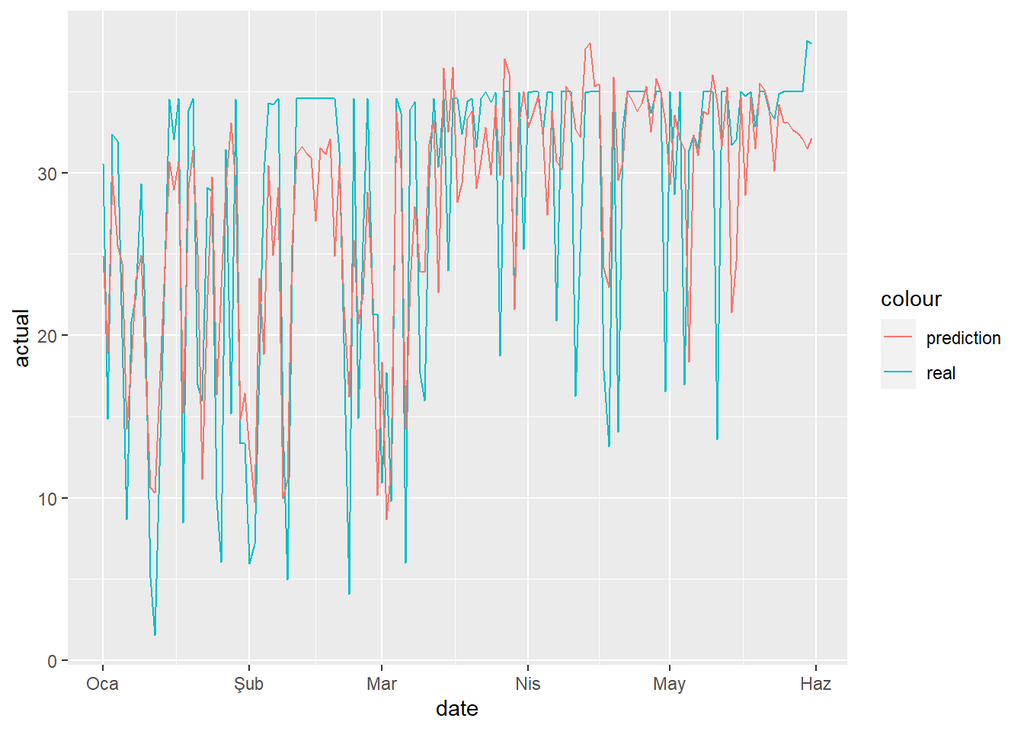

```r
ggplot(tmp,aes(x=date))+geom_line(aes(y=actual,color='real'))+geom_line(aes(y=predicted,color='prediction'))
```

```r
test<-dataph12[146,]
test$datetime=="2022-05-28 12:00:00"
test$date=as.Date("2022-05-28")
test$temp=299.9838
test$dswrf=839.3756
test$cloud_low_layer=0.06666667
test$rel_humidity=26.53333
test$hour=12
test$trend=146

tmp<-rbindlist(list(tmp,test),fill=T,use.names=T)

tail(tmp,15)
predicted<-predict(modelh12,tmp)
tmp$predicted<-predicted

tmp[is.na(production),production:=predicted]


tail(tmp,15)

test$datetime=="2022-05-29 12:00:00"
test$date=as.Date("2022-05-29")
test$temp=301.4111
test$dswrf=838.273
test$cloud_low_layer=0.0444444
test$rel_humidity= 25.74444
test$hour=12
test$trend=147



tmp<-rbindlist(list(tmp,test),fill=T,use.names=T)
tail(tmp,15)

predicted<-as.numeric(predict(modelh11,tmp))
tmp$predicted<-predicted


tail(tmp,15)


tmp[is.na(production),production:=predicted]

test$datetime=="2022-05-30 12:00:00"
test$date=as.Date("2022-05-30")
test$temp= 302.5087
test$dswrf=838.7644
test$cloud_low_layer= 0.05555556
test$rel_humidity= 24.95556
test$hour=12
test$trend=148
tmp<-rbindlist(list(tmp,test),fill=T,use.names=T)
tail(tmp,15)
predicted<-predict(modelh11,tmp)
tmp$predicted<-predicted
tmp$predicted[tmp$predicted>=35]=35

tail(tmp,15)
```

t=01.00 pm:

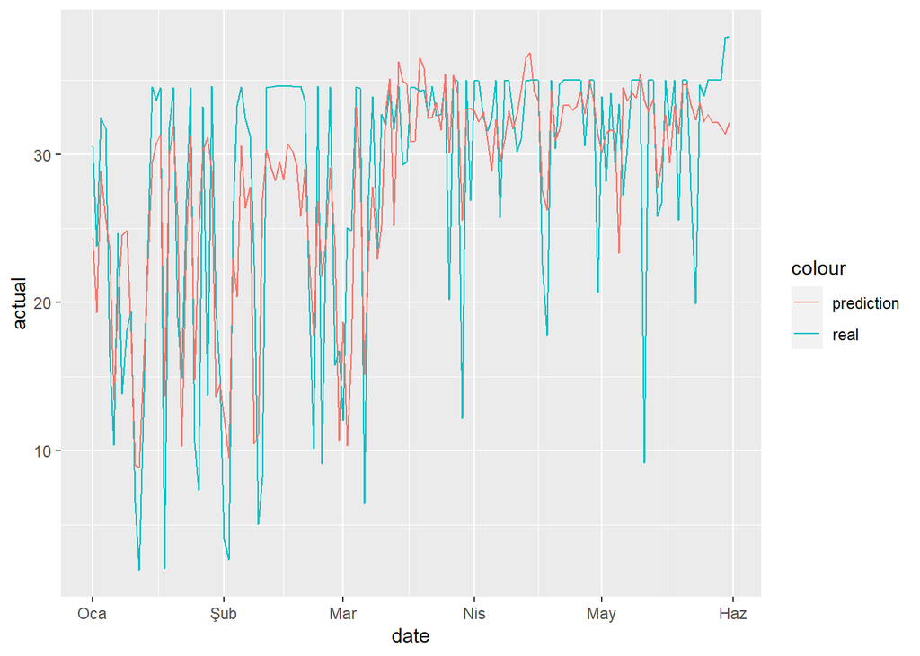

```r
dataph13[,trend:=1:.N]
modelh13<-lm(production~temp+dswrf+cloud_low_layer^3+rel_humidity^3,data=dataph13)
summary(modelh13)
tmp=copy(dataph13)
dataph13
predicted<-predict(modelh13,tmp)
predicted
tmp$actual<-tmp$production
#rmse(tmp$actual,predicted)
data2[datetime=="2022-06-03 16:00:00"]
ggplot(tmp,aes(x=date))+geom_line(aes(y=actual,color='real'))+geom_line(aes(y=predicted,color='prediction'))
```

```r
test<-dataph13[150,]
test$datetime=="2022-06-01 13:00:00"
test$date=as.Date("2022-06-01")
test$temp=301.2777
test$dswrf= 886.28
test$cloud_low_layer=   0.3111
test$rel_humidity=29.5777
test$hour=13
test$trend=150

tmp<-rbindlist(list(tmp,test),fill=T,use.names=T)

tail(tmp,15)
predicted<-predict(modelh12,tmp)
tmp$predicted<-predicted

tmp[is.na(production),production:=predicted]


tail(tmp,15)

test$datetime=="2022-06-02 13:00:00"
test$date=as.Date("2022-06-02")
test$temp=301.1825
test$dswrf=850.0355
test$cloud_low_layer=0
test$rel_humidity=28.9111
test$hour=13
test$trend=151



tmp<-rbindlist(list(tmp,test),fill=T,use.names=T)
tail(tmp,15)

predicted<-as.numeric(predict(modelh13,tmp))
tmp$predicted<-predicted


tail(tmp,15)


tmp[is.na(production),production:=predicted]

test$datetime=="2022-06-03 13:00:00"
test$date=as.Date("2022-06-03")
test$temp= 299.8876
test$dswrf=894.6466
test$cloud_low_layer= 0.2333
test$rel_humidity=30.3888
test$hour=13
test$trend=152
tmp<-rbindlist(list(tmp,test),fill=T,use.names=T)
tail(tmp,15)
predicted<-predict(modelh13,tmp)
tmp$predicted<-predicted
#tmp$predicted[tmp$predicted>=35]=35

tail(tmp,15)
```

t=02.00 pm:

```r
dataph14[,trend:=1:.N]
modelh14<-lm(production~temp+dswrf+cloud_low_layer^3+rel_humidity^3,data=dataph14)
summary(modelh14)
```

```
##
## Call:
## lm(formula = production ~ temp + dswrf + cloud_low_layer^3 +
##     rel_humidity^3, data = dataph14)
##
## Residuals:
##     Min      1Q  Median      3Q     Max
## -19.507  -4.274   1.433   4.136  18.396
##
## Coefficients:
##                  Estimate Std. Error t value Pr(>|t|)
## (Intercept)     131.86500   30.27213   4.356  2.5e-05 ***
## temp             -0.36342    0.10184  -3.569 0.000488 ***
## dswrf             0.01422    0.00536   2.654 0.008858 **
## cloud_low_layer  -0.07615    0.03483  -2.186 0.030408 *
## rel_humidity     -0.17200    0.07395  -2.326 0.021422 *
## ---
## Signif. codes:  0 '***' 0.001 '**' 0.01 '*' 0.05 '.' 0.1 ' ' 1
##
## Residual standard error: 7.276 on 144 degrees of freedom
## Multiple R-squared:  0.5088, Adjusted R-squared:  0.4951
## F-statistic: 37.28 on 4 and 144 DF,  p-value: < 2.2e-16
```

```r
tmp=copy(dataph14)
#dataph14
predicted<-predict(modelh14,tmp)
#predicted
tmp$actual<-tmp$production
#rmse(tmp$actual,predicted)
data2[datetime=="2022-06-03 16:00:00"]
```

```
##               datetime     temp    dswrf cloud_low_layer rel_humidity
## 1: 2022-06-03 13:00:00 299.8877 894.6467               0     30.38889
```

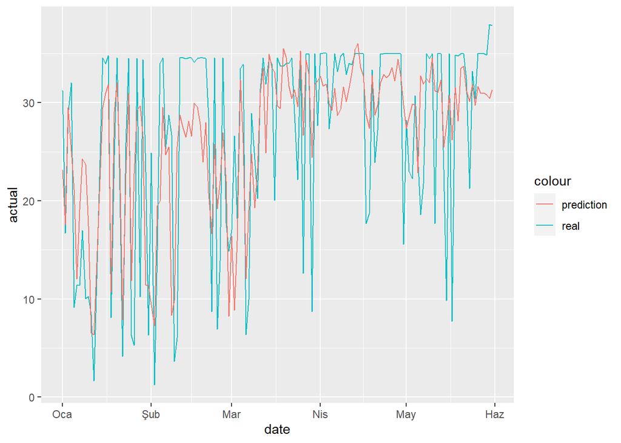

```r
ggplot(tmp,aes(x=date))+geom_line(aes(y=actual,color='real'))+geom_line(aes(y=predicted,color='prediction'))
```

```r
test<-dataph14[150,]
test$datetime=="2022-06-01 14:00:00"
test$date=as.Date("2022-06-01")
test$temp=301.2777
test$dswrf= 886.28
test$cloud_low_layer=   0.3111
test$rel_humidity=29.5777
test$hour=14
test$trend=150

tmp<-rbindlist(list(tmp,test),fill=T,use.names=T)

tail(tmp,15)
predicted<-predict(modelh14,tmp)
tmp$predicted<-predicted

tmp[is.na(production),production:=predicted]


tail(tmp,15)

test$datetime=="2022-06-02 14:00:00"
test$date=as.Date("2022-06-02")
test$temp=301.1825
test$dswrf=850.0355
test$cloud_low_layer=0
test$rel_humidity=28.9111
test$hour=14
test$trend=151



tmp<-rbindlist(list(tmp,test),fill=T,use.names=T)
tail(tmp,15)

predicted<-as.numeric(predict(modelh14,tmp))
tmp$predicted<-predicted


tail(tmp,15)


tmp[is.na(production),production:=predicted]

test$datetime=="2022-06-03 14:00:00"
test$date=as.Date("2022-06-03")
test$temp= 299.8876
test$dswrf=894.6466
test$cloud_low_layer= 0.2333
test$rel_humidity=30.3888
test$hour=14
test$trend=152
tmp<-rbindlist(list(tmp,test),fill=T,use.names=T)
tail(tmp,15)
predicted<-predict(modelh14,tmp)
tmp$predicted<-predicted
#tmp$predicted[tmp$predicted>=35]=35

tail(tmp,15)
```

t=03.00 pm :

```r
dataph15[,trend:=1:.N]
lag15<-shift(dataph15$production, n=15L, fill=NA)
lag14<-shift(dataph15$production, n=14L, fill=NA)
dataph15$lag15<-lag15
dataph15$lag14<-lag14
#season15<-as.factor(quarter(dataph15$date))

modelh15<-lm(production~dswrf+log(cloud_low_layer +1)+log(lag15)+lag14+trend,data=dataph15)
summary(modelh15)
```

```
##
## Call:
## lm(formula = production ~ dswrf + log(cloud_low_layer + 1) +
##     log(lag15) + lag14 + trend, data = dataph15)
##
## Residuals:
##      Min       1Q   Median       3Q      Max
## -18.5560  -3.4241   0.3351   4.0433  18.1976
##
## Coefficients:
##                           Estimate Std. Error t value Pr(>|t|)
## (Intercept)              16.183800   4.343177   3.726  0.00029 ***
## dswrf                     0.035499   0.005875   6.042 1.54e-08 ***
## log(cloud_low_layer + 1) -2.728074   0.564904  -4.829 3.84e-06 ***
## log(lag15)                2.270245   0.844737   2.688  0.00816 **
## lag14                    -0.142288   0.058412  -2.436  0.01623 *
## trend                    -0.138879   0.030518  -4.551 1.23e-05 ***
## ---
## Signif. codes:  0 '***' 0.001 '**' 0.01 '*' 0.05 '.' 0.1 ' ' 1
##
## Residual standard error: 7.61 on 128 degrees of freedom
##   (15 observations deleted due to missingness)
## Multiple R-squared:  0.5809, Adjusted R-squared:  0.5645
## F-statistic: 35.48 on 5 and 128 DF,  p-value: < 2.2e-16
```

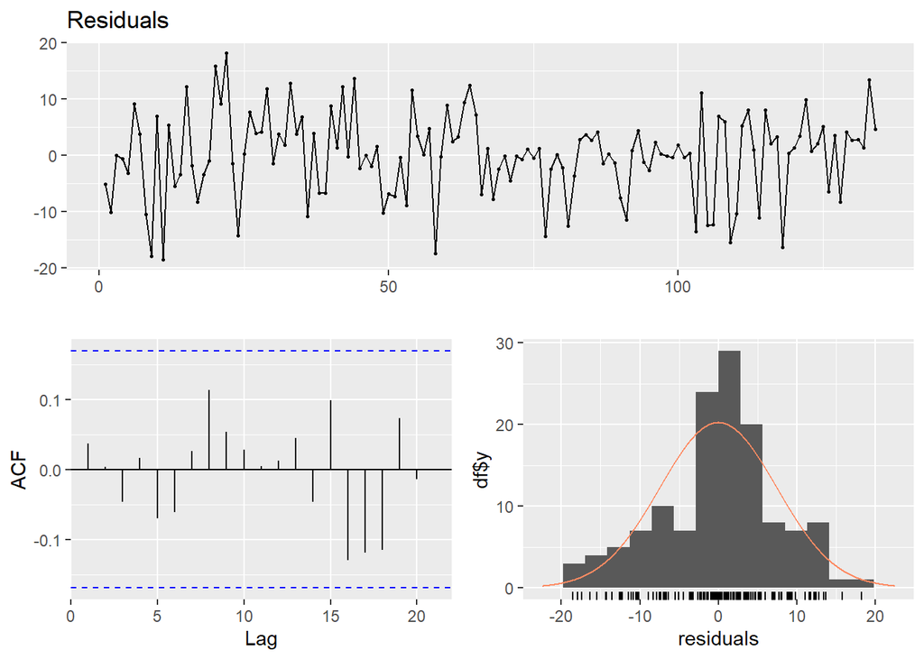

```
##
##  Breusch-Godfrey test for serial correlation of order up to 10
##
## data:  Residuals
## LM test = 3.9398, df = 10, p-value = 0.95
```

```r
checkresiduals(modelh15)
```

```r
tmp=copy(dataph15)
predicted<-predict(modelh15,tmp)
#predicted
tmp$actual<-tmp$production
#rmse(tmp$actual,predicted)
data2[datetime=="2022-06-03 18:00:00"]
```

```
##               datetime     temp    dswrf cloud_low_layer rel_humidity
## 1: 2022-06-03 15:00:00 300.6522 918.2844               0     27.08889
```

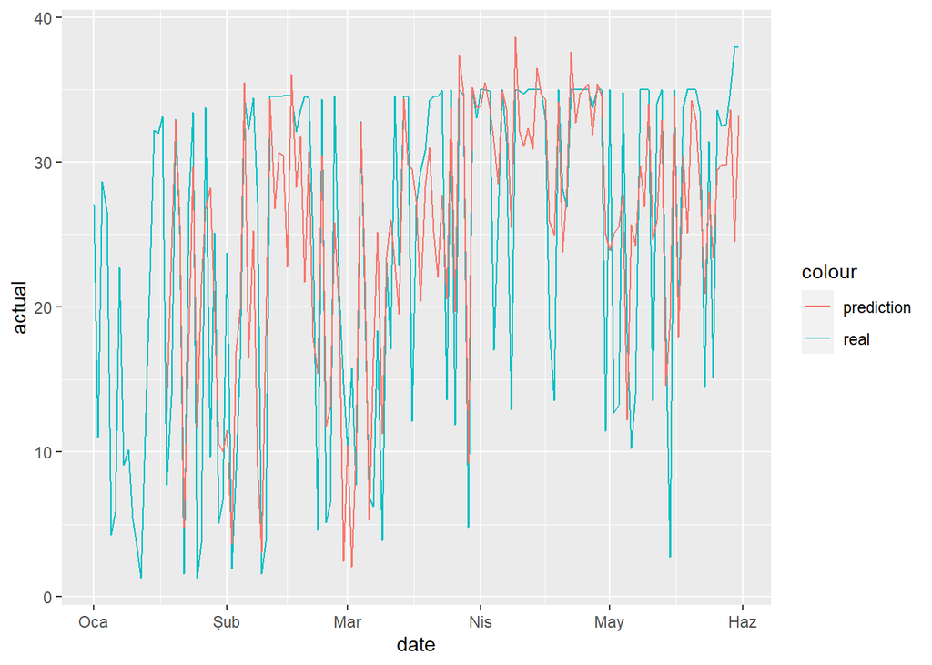

```r
ggplot(tmp,aes(x=date))+geom_line(aes(y=actual,color='real'))+geom_line(aes(y=predicted,color='prediction'))
```

```r
test<-dataph15[150,]
test$datetime=="2022-06-01 15:00:00"
test$date=as.Date("2022-06-01")
test$temp=301.6591
test$dswrf=902.3253
test$cloud_low_layer=   0.4222
test$rel_humidity=28.8888
test$hour=15
test$trend=150

tmp<-rbindlist(list(tmp,test),fill=T,use.names=T)

tail(tmp,15)
predicted<-predict(modelh15,tmp)
tmp$predicted<-predicted

tmp[is.na(production),production:=predicted]


tail(tmp,15)

test$datetime=="2022-06-02 15:00:00"
test$date=as.Date("2022-06-02")
test$temp=302.3927
test$dswrf=876.0462
test$cloud_low_layer=0
test$rel_humidity=24.5333
test$hour=15
test$trend=151



tmp<-rbindlist(list(tmp,test),fill=T,use.names=T)
tail(tmp,15)

predicted<-as.numeric(predict(modelh15,tmp))
tmp$predicted<-predicted


tail(tmp,15)


tmp[is.na(production),production:=predicted]

test$datetime=="2022-06-03 15:00:00"
test$date=as.Date("2022-06-03")
test$temp= 300.6522
test$dswrf=918.2844
test$cloud_low_layer= 0
test$rel_humidity=27.0888
test$hour=15
test$trend=152
tmp<-rbindlist(list(tmp,test),fill=T,use.names=T)
tail(tmp,15)
predicted<-predict(modelh15,tmp)
tmp$predicted<-predicted
#tmp$predicted[tmp$predicted>=38.50]=40

tail(tmp,15)
```

t=04.00 pm:

```r
dataph16[,trend:=1:.N]
lag8<-shift(dataph16$production, n=5L, fill=NA)
dataph16$lag8<-lag8
season16<-as.factor(quarter(dataph16$date))

modelh16<-lm(production~dswrf+log(cloud_low_layer+1)+temp^2,data=dataph16)
modelh16$season16<-season16
summary(modelh16)
```

```
##
## Call:
## lm(formula = production ~ dswrf + log(cloud_low_layer + 1) +
##     temp^2, data = dataph16)
##
## Residuals:
##      Min       1Q   Median       3Q      Max
## -21.6559  -3.9409   0.9165   4.6636  24.1098
##
## Coefficients:
##                           Estimate Std. Error t value Pr(>|t|)
## (Intercept)              64.654476  25.703897   2.515   0.0130 *
## dswrf                     0.034997   0.004079   8.579 1.34e-14 ***
## log(cloud_low_layer + 1) -2.163533   0.481333  -4.495 1.41e-05 ***
## temp                     -0.199986   0.091404  -2.188   0.0303 *
## ---
## Signif. codes:  0 '***' 0.001 '**' 0.01 '*' 0.05 '.' 0.1 ' ' 1
##
## Residual standard error: 7.247 on 145 degrees of freedom
## Multiple R-squared:  0.6322, Adjusted R-squared:  0.6246
## F-statistic: 83.07 on 3 and 145 DF,  p-value: < 2.2e-16
```

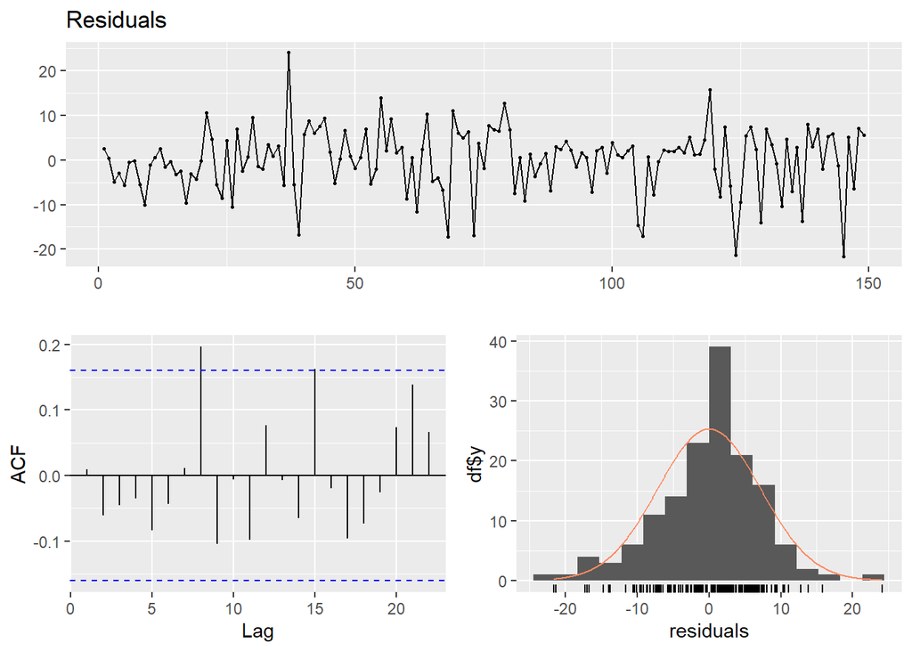

```
##
##  Breusch-Godfrey test for serial correlation of order up to 10
##
## data:  Residuals
## LM test = 10.687, df = 10, p-value = 0.3824
```

```r
checkresiduals(modelh16)
```

```r
tmp=copy(dataph16)
predicted<-predict(modelh16,tmp)
tmp$actual<-tmp$production
#rmse(tmp$actual,predicted)
data2[datetime=="2022-06-03 19:00:00"]
```

```
##               datetime     temp    dswrf cloud_low_layer rel_humidity
## 1: 2022-06-03 16:00:00 300.4403 802.2133               0     26.34444
```

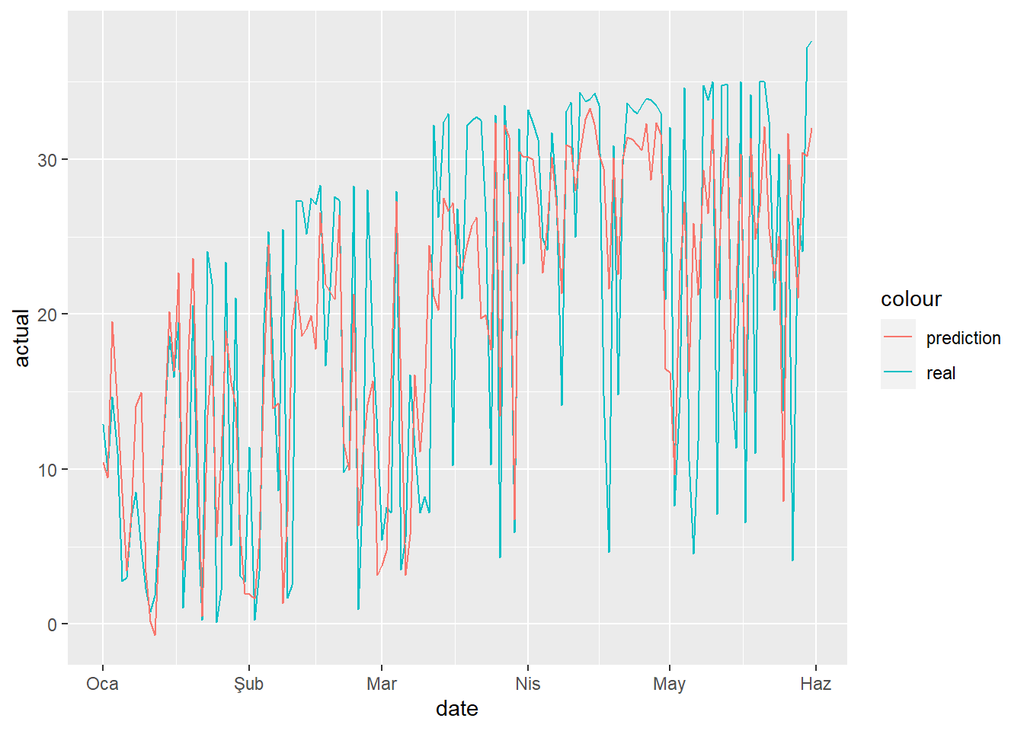

```r
ggplot(tmp,aes(x=date))+geom_line(aes(y=actual,color='real'))+geom_line(aes(y=predicted,color='prediction'))
```

```r
test<-dataph16[150,]
test$datetime=="2022-06-01 16:00:00"
test$date=as.Date("2022-06-01")
test$temp=301.325
test$dswrf= 765.8177
test$cloud_low_layer=0.6888
test$rel_humidity=27.5444
test$hour=16
test$trend=150

tmp<-rbindlist(list(tmp,test),fill=T,use.names=T)

tail(tmp,15)
predicted<-predict(modelh16,tmp)
tmp$predicted<-predicted

tmp[is.na(production),production:=predicted]


tail(tmp,15)

test$datetime=="2022-06-02 16:00:00"
test$date=as.Date("2022-06-02")
test$temp=302.2915
test$dswrf=778.32
test$cloud_low_layer=0
test$rel_humidity=24.9888
test$hour=16
test$trend=151



tmp<-rbindlist(list(tmp,test),fill=T,use.names=T)
tail(tmp,15)

predicted<-as.numeric(predict(modelh16,tmp))
tmp$predicted<-predicted


tail(tmp,15)


tmp[is.na(production),production:=predicted]

test$datetime=="2022-06-03 16:00:00"
test$date=as.Date("2022-06-03")
test$temp= 300.4403
test$dswrf=802.2133
test$cloud_low_layer=0
test$rel_humidity=26.3444
test$hour=16
test$trend=151
tmp<-rbindlist(list(tmp,test),fill=T,use.names=T)
tail(tmp,15)
predicted<-predict(modelh16,tmp)
tmp$predicted<-predicted
#tmp$predicted[tmp$predicted>=40]=40

tail(tmp,15)
```

t=5.00 pm:

```r
dataph17[,trend:=1:.N]
#dataph17
lag5<-shift(dataph17$production, n=9L, fill=NA)
dataph17$lag5<-lag5
#modelh17$season17<-as.factor(month(dataph17$date))
modelh17<-lm(production~dswrf+temp^2,data=dataph17)
summary(modelh17)
```

```
##
## Call:
## lm(formula = production ~ dswrf + temp^2, data = dataph17)
##
## Residuals:
##      Min       1Q   Median       3Q      Max
## -17.2468  -2.4036   0.2326   3.2327  10.1138
##
## Coefficients:
##               Estimate Std. Error t value Pr(>|t|)
## (Intercept) -53.044324  15.724419  -3.373 0.000951 ***
## dswrf         0.028048   0.002498  11.227  < 2e-16 ***
## temp          0.181834   0.057576   3.158 0.001930 **
## ---
## Signif. codes:  0 '***' 0.001 '**' 0.01 '*' 0.05 '.' 0.1 ' ' 1
##
## Residual standard error: 4.537 on 146 degrees of freedom
## Multiple R-squared:  0.6786, Adjusted R-squared:  0.6742
## F-statistic: 154.1 on 2 and 146 DF,  p-value: < 2.2e-16
```

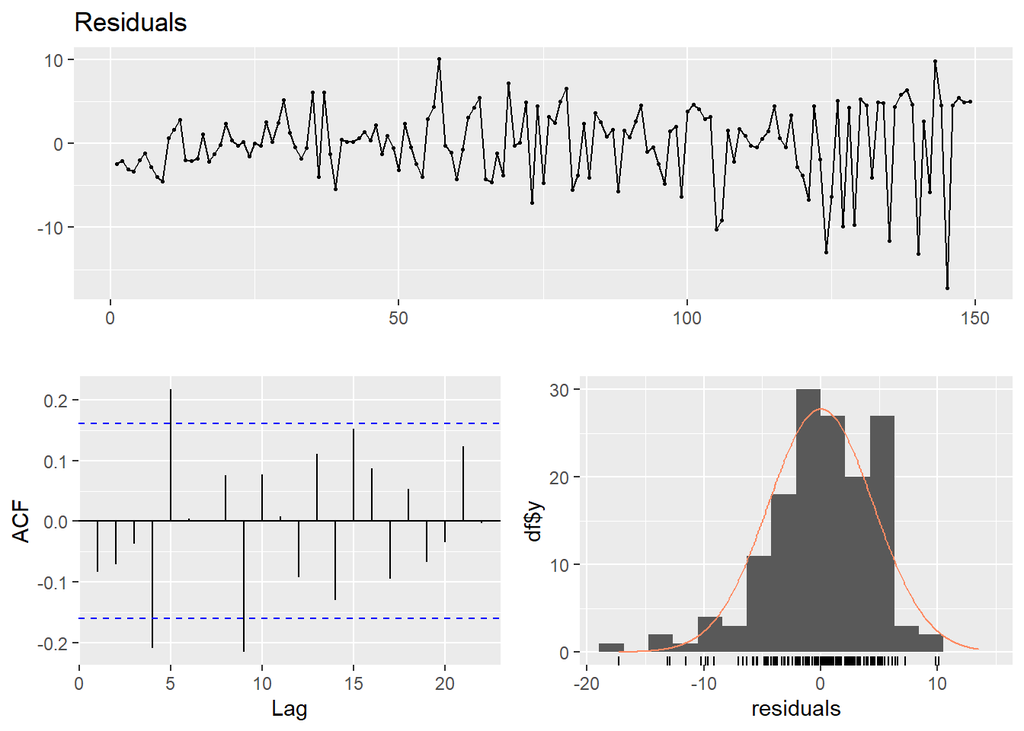

```
##
##  Breusch-Godfrey test for serial correlation of order up to 10
##
## data:  Residuals
## LM test = 20.631, df = 10, p-value = 0.02382
```

```r
checkresiduals(modelh17)
```

```r
tmp=copy(dataph17)
predicted<-predict(modelh17,tmp)
tmp$actual<-tmp$production
#rmse(tmp$actual,predicted)
data2[datetime=="2022-06-03 20:00:00"]
```

```
##               datetime     temp  dswrf cloud_low_layer rel_humidity
## 1: 2022-06-03 17:00:00 299.6568 717.04               0     26.66667
```

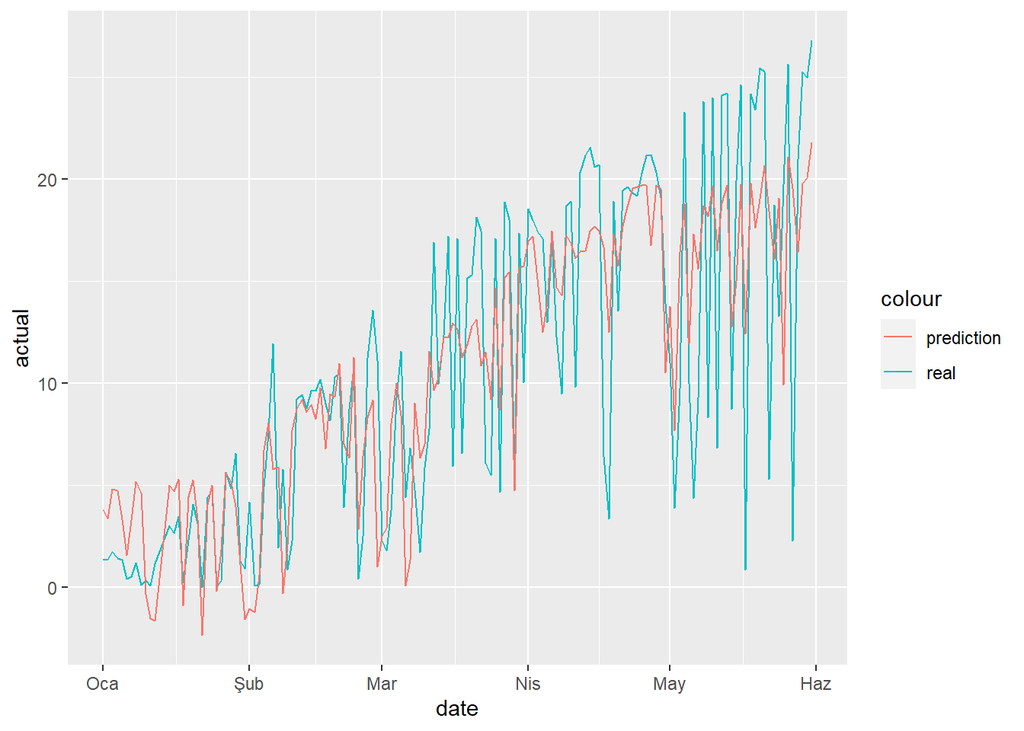

```r
ggplot(tmp,aes(x=date))+geom_line(aes(y=actual,color='real'))+geom_line(aes(y=predicted,color='prediction'))
```

```r
test<-dataph17[150,]
test$datetime=="2022-06-01 17:00:00"
test$date=as.Date("2022-06-01")
test$temp=300.5918
test$dswrf= 676.0822
test$cloud_low_layer=0.8888
test$rel_humidity=28.1444
test$hour=17
test$trend=150

tmp<-rbindlist(list(tmp,test),fill=T,use.names=T)

tail(tmp,15)
predicted<-predict(modelh17,tmp)
tmp$predicted<-predicted

tmp[is.na(production),production:=predicted]


tail(tmp,15)

test$datetime=="2022-06-02 17:00:00"
test$date=as.Date("2022-06-02")
test$temp=301.6315
test$dswrf=694.8133
test$cloud_low_layer=0
test$rel_humidity=26.0888
test$hour=17
test$trend=151



tmp<-rbindlist(list(tmp,test),fill=T,use.names=T)
tail(tmp,15)

predicted<-as.numeric(predict(modelh17,tmp))
tmp$predicted<-predicted


tail(tmp,15)


tmp[is.na(production),production:=predicted]

test$datetime=="2022-06-03 17:00:00"
test$date=as.Date("2022-06-03")
test$temp= 299.6567
test$dswrf=717.04
test$cloud_low_layer=0
test$rel_humidity=26.6666
test$hour=17
test$trend=152
tmp<-rbindlist(list(tmp,test),fill=T,use.names=T)
tail(tmp,15)
predicted<-predict(modelh17,tmp)
tmp$predicted<-predicted
#tmp$predicted[tmp$predicted>=40]=40

tail(tmp,15)
```

t=06.00 pm:

```r
lag1<-shift(dataph18$production, n=1L, fill=NA)
dataph18$lag1<-lag1
dataph18$season<-as.factor(quarter(dataph18$date))
#trend<-c(1:nrow((dataph19)))
#dataph19$trend<-trend
modelh18<-lm(production~dswrf+temp+lag1+season,data=dataph18)
summary(modelh18)
```

```
##
## Call:
## lm(formula = production ~ dswrf + temp + lag1 + season, data = dataph18)
##
## Residuals:
##     Min      1Q  Median      3Q     Max
## -5.6321 -0.6801 -0.0171  0.6076  4.0770
##
## Coefficients:
##               Estimate Std. Error t value Pr(>|t|)
## (Intercept) -29.290026   8.011815  -3.656 0.000359 ***
## dswrf         0.005929   0.001095   5.412 2.56e-07 ***
## temp          0.102712   0.028890   3.555 0.000512 ***
## lag1          0.216623   0.077273   2.803 0.005760 **
## season2       0.788143   0.542628   1.452 0.148565
## ---
## Signif. codes:  0 '***' 0.001 '**' 0.01 '*' 0.05 '.' 0.1 ' ' 1
##
## Residual standard error: 1.413 on 143 degrees of freedom
##   (1 observation deleted due to missingness)
## Multiple R-squared:  0.783,  Adjusted R-squared:  0.7769
## F-statistic:   129 on 4 and 143 DF,  p-value: < 2.2e-16
```

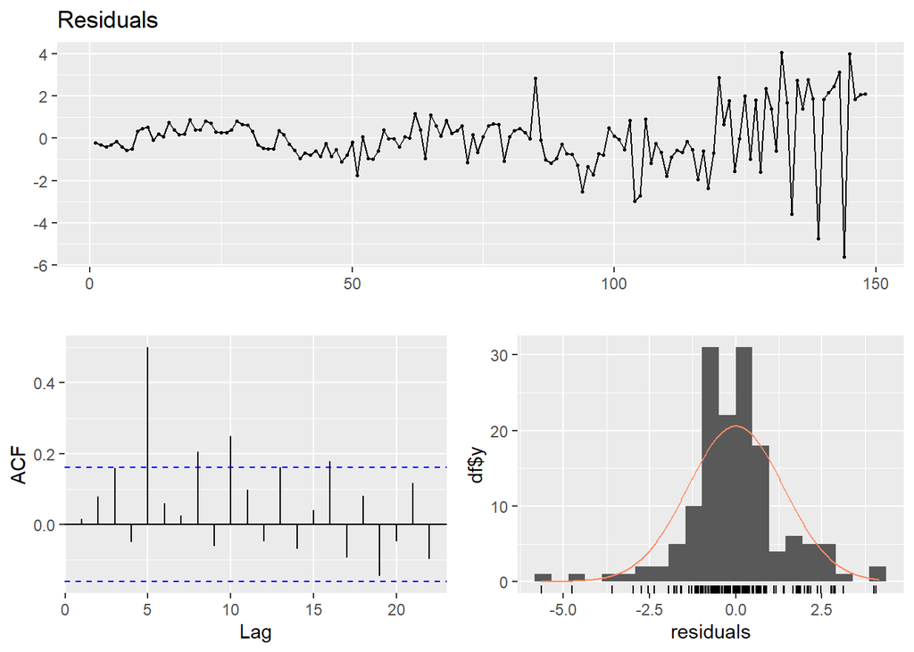

```
##
##  Breusch-Godfrey test for serial correlation of order up to 10
##
## data:  Residuals
## LM test = 52.377, df = 10, p-value = 9.715e-08
```

```r
checkresiduals(modelh18)
```

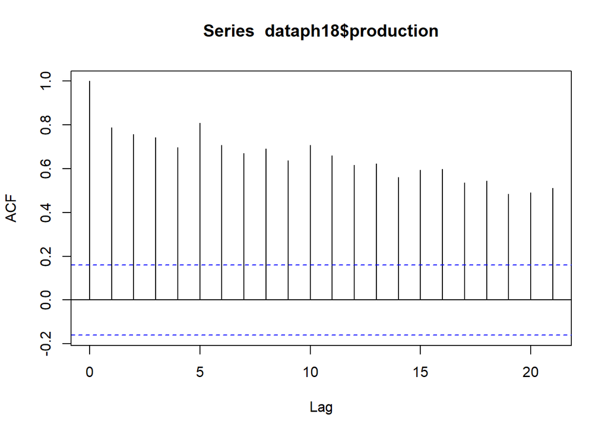

```r
acf(dataph18$production)
```

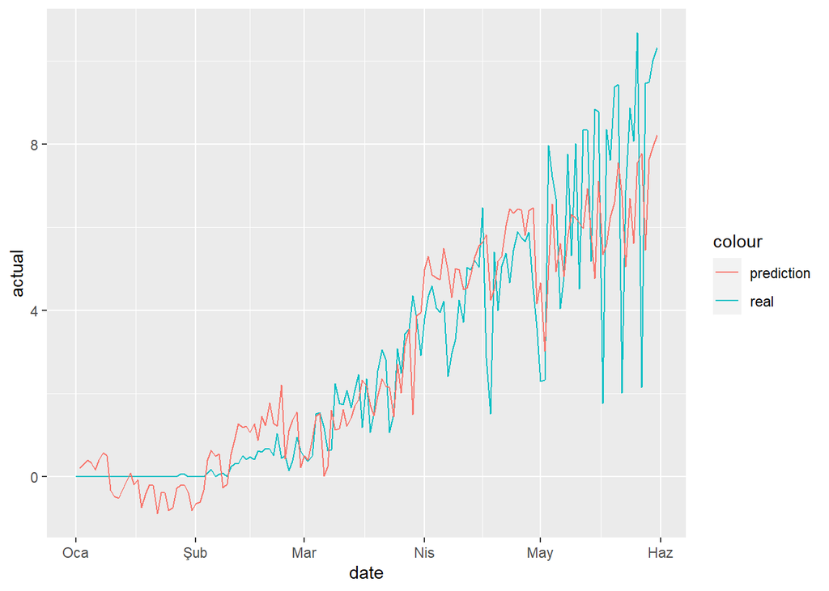

```r
tmp=copy(dataph18)
predicted<-predict(modelh18,tmp)
tmp$actual<-tmp$production
#rmse(tmp$actual, tmp$predicted,na.rm=TRUE)
ggplot(tmp,aes(x=date))+geom_line(aes(y=actual,color='real'))+geom_line(aes(y=predicted,color='prediction'))
```

```r
test<-dataph18[147,]
test$datetime=="2022-05-29 18:00:00"
test$date=as.Date("2022-05-29")
test$temp=300.3162
test$dswrf= 547.0822
test$cloud_low_layer=    0.5555556
test$rel_humidity=29.08889
test$hour=18
test$lag1=9.47
test$season=as.factor(quarter(test$date))
tmp<-rbindlist(list(tmp,test),fill=T,use.names=T)

tail(tmp,15)



tail(tmp,15)
predicted<-predict(modelh18,tmp)
tmp$predicted<-predicted

tmp[is.na(production),production:=predicted]


tail(tmp,15)

test$datetime=="2022-05-30 06:00:00"
test$date=as.Date("2022-05-30")
test$temp=302.3384
test$dswrf=585.2489
test$cloud_low_layer=  0.03333333
test$rel_humidity=20.13333
test$hour=18
test$lag1=7.149623
test$season=as.factor(quarter(test$date))
tmp<-rbindlist(list(tmp,test),fill=T,use.names=T)
tail(tmp,15)

predicted<-predict(modelh18,tmp)
tmp$predicted<-predicted

tail(tmp,15)


tmp[is.na(production),production:=predicted]

test$datetime=="2022-05-31 06:00:00"
test$date=as.Date("2022-05-31")
test$temp= 300.5444
test$dswrf=618.4689
test$cloud_low_layer=  0
test$rel_humidity=  20.6
test$hour=18
test$lag1=7.190887
test$season=as.factor(quarter(test$date))
tmp<-rbindlist(list(tmp,test),fill=T,use.names=T)
tail(tmp,15)
predicted<-predict(modelh18,tmp)
tmp$predicted<-predicted

tail(tmp,15)
```

t=07.00 pm:

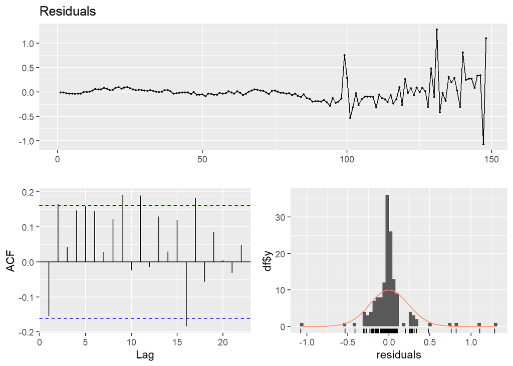

```r
lag1<-shift(dataph19$production, n=1L, fill=NA)
dataph19$lag1<-lag1
dataph19$season<-as.factor(quarter(dataph19$date))
#trend<-c(1:nrow((dataph19)))
#dataph19$trend<-trend
modelh19<-lm(production~dswrf+temp+lag1+season,data=dataph19)
summary(modelh19)
checkresiduals(modelh19)
```

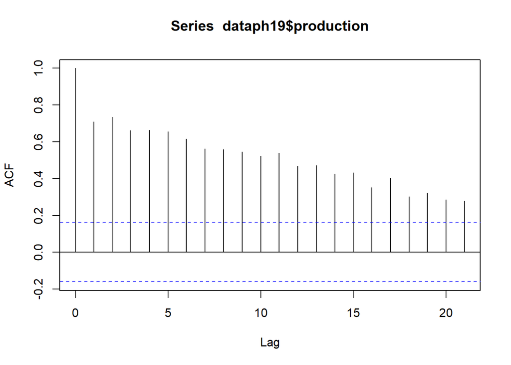

```r
acf(dataph19$production)
```

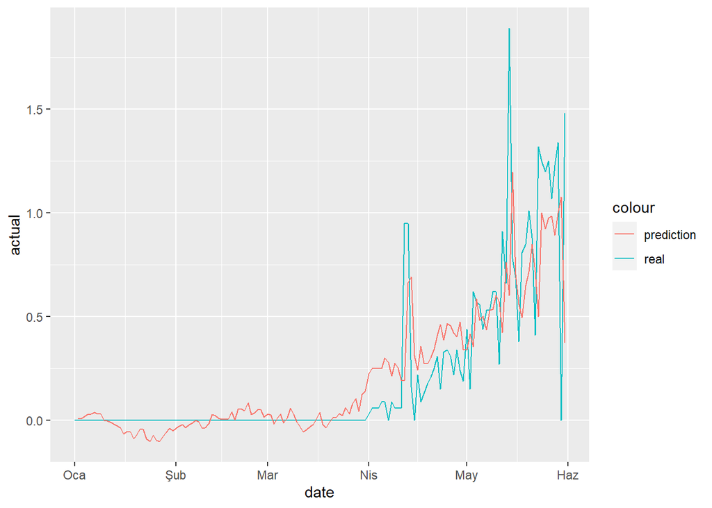

```r
tmp=copy(dataph19)
predicted<-predict(modelh19,tmp)
tmp$actual<-tmp$production
#rmse(tmp$actual, tmp$predicted,na.rm=TRUE)
ggplot(tmp,aes(x=date))+geom_line(aes(y=actual,color='real'))+geom_line(aes(y=predicted,color='prediction'))
```

```r
test<-dataph19[147,]
test$datetime=="2022-05-29 19:00:00"
test$date=as.Date("2022-05-29")
test$temp=299.3127
test$dswrf=442.9733
test$cloud_low_layer=   1.122222
test$rel_humidity=33.05556
test$hour=19
test$lag1=1.23
test$season=as.factor(quarter(test$date))
tmp<-rbindlist(list(tmp,test),fill=T,use.names=T)

tail(tmp,15)



tail(tmp,15)
predicted<-predict(modelh19,tmp)
tmp$predicted<-predicted

tmp[is.na(production),production:=predicted]


tail(tmp,15)

test$datetime=="2022-05-30 06:00:00"
test$date=as.Date("2022-05-30")
test$temp=300.7123
test$dswrf=493.2111
test$cloud_low_layer=0
test$rel_humidity=25.44444
test$hour=19
test$lag1=1.0643857
test$season=as.factor(quarter(test$date))
tmp<-rbindlist(list(tmp,test),fill=T,use.names=T)
tail(tmp,15)

predicted<-predict(modelh19,tmp)
tmp$predicted<-predicted

tail(tmp,15)


tmp[is.na(production),production:=predicted]

test$datetime=="2022-05-31 06:00:00"
test$date=as.Date("2022-05-31")
test$temp= 299.024
test$dswrf=518.5778
test$cloud_low_layer=  0
test$rel_humidity= 25.17778
test$hour=19
test$lag1= 0.9746842
test$season=as.factor(quarter(test$date))
tmp<-rbindlist(list(tmp,test),fill=T,use.names=T)
tail(tmp,15)
predicted<-predict(modelh19,tmp)
tmp$predicted<-predicted

tail(tmp,15)
```

t=08.00 pm:

```r
lag1<-shift(dataph20$production, n=1L, fill=NA)
dataph20$lag1<-lag1
dataph20$season<-as.factor(quarter(dataph20$date))
#trend<-c(1:nrow((dataph19)))
#dataph19$trend<-trend
modelh20<-lm(production~dswrf+temp+lag1+season,data=dataph20)
summary(modelh20)
```

```
##
## Call:
## lm(formula = production ~ dswrf + temp + lag1 + season, data = dataph20)
##
## Residuals:
##       Min        1Q    Median        3Q       Max
## -0.003906 -0.002285 -0.000808  0.000258  0.147044
##
## Coefficients:
##               Estimate Std. Error t value Pr(>|t|)
## (Intercept)  4.427e-02  7.065e-02   0.627    0.532
## dswrf        2.258e-06  1.383e-05   0.163    0.871
## temp        -1.618e-04  2.555e-04  -0.633    0.528
## lag1        -1.827e-02  8.352e-02  -0.219    0.827
## season2      4.230e-03  4.788e-03   0.884    0.378
##
## Residual standard error: 0.01242 on 143 degrees of freedom
##   (1 observation deleted due to missingness)
## Multiple R-squared:  0.01304,    Adjusted R-squared:  -0.01457
## F-statistic: 0.4722 on 4 and 143 DF,  p-value: 0.7561
```

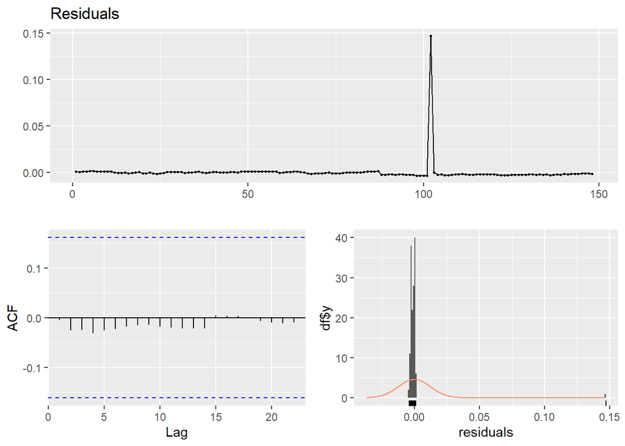

```
##
##  Breusch-Godfrey test for serial correlation of order up to 10
##
## data:  Residuals
## LM test = 2.6029, df = 10, p-value = 0.9893
```

```r
checkresiduals(modelh20)
```

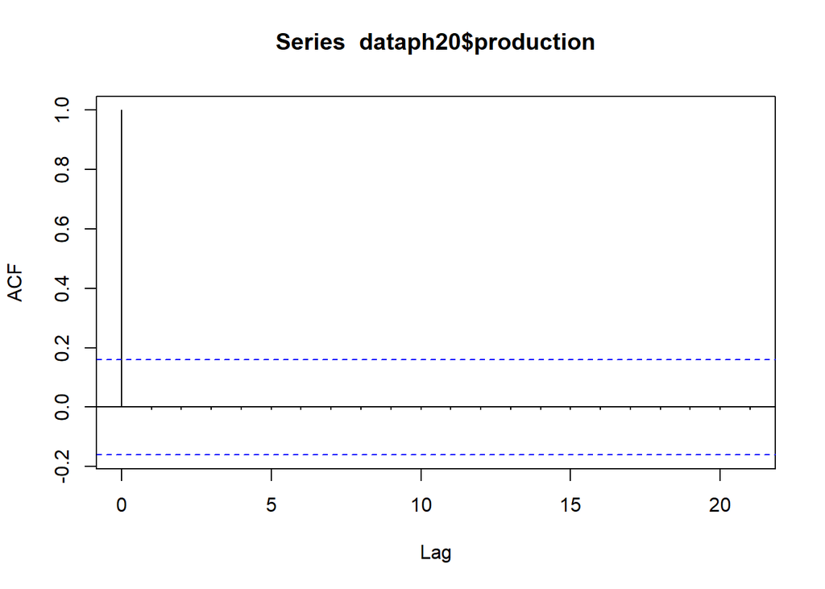

```r
acf(dataph20$production)
```

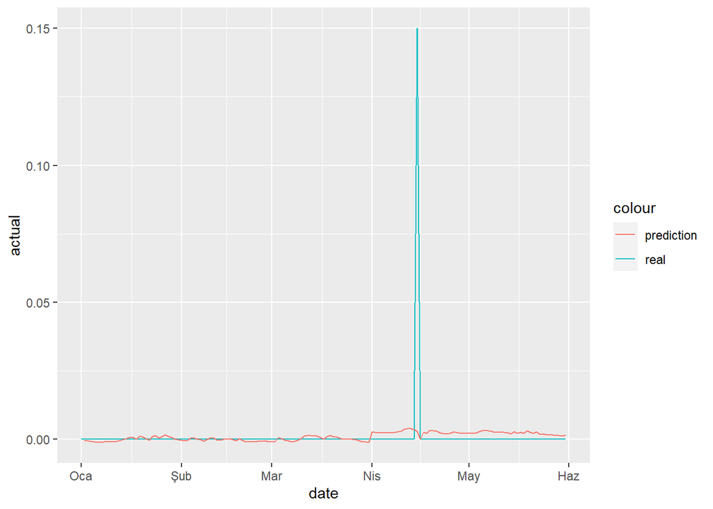

```r
tmp=copy(dataph20)
predicted<-predict(modelh20,tmp)
tmp$actual<-tmp$production
#rmse(tmp$actual, tmp$predicted,na.rm=TRUE)
ggplot(tmp,aes(x=date))+geom_line(aes(y=actual,color='real'))+geom_line(aes(y=predicted,color='prediction'))
```

```r
test<-dataph20[147,]
test$datetime=="2022-05-29 20:00:00"
test$date=as.Date("2022-05-29")
test$temp=299.3127
test$dswrf=442.9733
test$cloud_low_layer=   1.122222
test$rel_humidity=33.05556
test$hour=20
test$lag1=1.23
test$season=as.factor(quarter(test$date))
tmp<-rbindlist(list(tmp,test),fill=T,use.names=T)

tail(tmp,15)



tail(tmp,15)
predicted<-predict(modelh20,tmp)
tmp$predicted<-predicted

tmp[is.na(production),production:=predicted]


tail(tmp,15)

test$datetime=="2022-05-30 20:00:00"
test$date=as.Date("2022-05-30")
test$temp=300.7123
test$dswrf=493.2111
test$cloud_low_layer=0
test$rel_humidity=25.44444
test$hour=20
test$lag1=1.0643857
test$season=as.factor(quarter(test$date))
tmp<-rbindlist(list(tmp,test),fill=T,use.names=T)
tail(tmp,15)

predicted<-predict(modelh20,tmp)
tmp$predicted<-predicted

tail(tmp,15)


tmp[is.na(production),production:=predicted]

test$datetime=="2022-05-31 20:00:00"
test$date=as.Date("2022-05-31")
test$temp= 299.024
test$dswrf=518.5778
test$cloud_low_layer=  0
test$rel_humidity= 25.17778
test$hour=20
test$lag1= 0.9746842
test$season=as.factor(quarter(test$date))
tmp<-rbindlist(list(tmp,test),fill=T,use.names=T)
tail(tmp,15)
predicted<-predict(modelh20,tmp)
tmp$predicted<-predicted

tail(tmp,15)
```

In this approach, we built a different model for each hour and generally dswrf has significant effect on production amounts. It can be seen from the summary tables of models that different parameters have different significance on each hour’s model. We tried to improve our models by using different regressors.

## 4. Results

By calculating WMAPE values of our predictions day-by-day during the competition phase - 0.0270497621, 0.1475246277, 0.07585580209, 0.08897036815 0.1119473545, 0.12417366, 0.2013595874- it can be said that our model is good enough to use for prediction. However, it is seen that our WMPAE values have increased towards the end of the competition period. It might need to be improved by using different approach.

## 5. Conclusions and Future Work

For this project, we first have analyzed the given data and made required data preparation and manipulation.We selected linear regression approach based on hour-by-hour production amount as our model. Although our hour-by-hour model worked well at the beginning of the competition, we have encountered some problems towards to end of the competition period. This situation might be related with the maximum production amount determined by regulation has changed. Because of that regulation , in our model, we limited the maximum amount of production. Instead of limiting the maximum amount , we might consider the capacity of the panels for the last days. There were some days that have extraordinary production amounts unrelated to our regression variables. There might be a problem with the panels or something else happened. We could not determine a certain reason to describe this kind of extraordinary situation with dummy variables. So, these outliers could not be modeled. Also, dependency between consecutive days is very strong at noon hours. Depending on the length of the days, the changing sun exposure times especially affect the morning hours of the day. This effect is explained by the trend variable in our model. However, better modeling is required for this situation which will change after June 21. Using accurate time series regression instead of linear regression would be more effective at that time period. By using different approaches, such as ARIMA/SARIMA/Exponential Smoothing Method, we might build better models. In addition to build new models with different approaches, other factors might be investigated to analyze data more detailed. Thus, better predictions might be obtained.

### References

AlKandari & Ahmad,2019.“Solar power generation forecasting using ensemble approach based on deep learning and statistical methods”, Retrieved June 4,2022. [link](https://www.emerald.com/insight/content/doi/10.1016/j.aci.2019.11.002/full/pdf?title=solar-power-generation-forecasting-using-ensemble-approach-based-on-deep-learning-and-statistical-methods)